# Envisioning Neighborhood Futures After the Chinatown Stitch

Aki Di Sandro, Ray Ma, Luming Xu, Sijia Zhang, Yixuan Zhou

2025-05-03

```r
knitr::opts_chunk$set(echo = TRUE, warning = FALSE, message = FALSE, cache = FALSE, fig.show = "asis",
    fig.align = "center")
options(scipen=999)


library(sf)
library(ggplot2)
library(tidycensus)
library(tidyverse)
library(ggtext)
library(glue)
library(leaflet)
library(mapview)
library(patchwork)
library(lwgeom)
library(FNN)
library(kableExtra)
library(corrplot)
library(htmltools)  # For div() function
library(knitr) # insert images
library(rsample)
library(tidymodels)
library(spatialsample)
library(glmnet)
library(ranger)
library(xgboost)
library(stars)
library(terra)
library(nngeo)
library(finetune)
library(themis)
library(applicable)
library(vetiver)
library(bayesplot)
library(lme4)
library(RcppEigen)
library(dplyr)
library(broom)


source("https://raw.githubusercontent.com/urbanSpatial/Public-Policy-Analytics-Landing/master/functions.r")
```

```r
# Change to your own workspace
knitr::opts_knit$set(root.dir = "E:/Spring/Practicum/DataAnalysis/Chinatown") # Luming
wd <- "E:/Spring/Practicum/DataAnalysis/Chinatown"

# Aki
# knitr::opts_knit$set(root.dir = "~/Documents/MUSA/Spring25/MUSA8010_Practicum/Chinatown-Practicum/")
# wd <- "~/Documents/MUSA/Spring25/MUSA8010_Practicum/Chinatown-Practicum/"

nhoods_4326 <-
  st_read("DataWrangling/data/philadelphia-neighborhoods.geojson") %>% # Luming
  # st_read("akidata/philadelphia-neighborhoods.geojson") %>% # Aki
  st_transform('EPSG:4326')

# philly properties (from Sijia)
# from the last 5 years, inflation-adjusted prices, total area > 100 sq ft, prices > 30,000, outliers above 5 SD from the mean were removed
# philly_properties <- st_read("akidata/property_philly.geojson") # Aki, from most recent update, 4/21/25, 88,571 rows
philly_properties <- st_read("DataWrangling/data/property_philly_cleaned.geojson") # Luming
```

# 1 Use Case

## 1.1 Background

It is hard to talk about the history of the **Philadelphia Chinatown** without the construction of **I-676**, also known as the **Vine Street Expressway**. Although the highway serves as a significant thoroughfare through Center City Philadelphia, the indispensable repercussion on the adjacent neighborhoods still lingers today. Consequences of the highway such as demolishment of buildings, pedestrian safety threats, traffic congestion, as well as noise and air pollutions had been harming Chinatown and its surrounding neighborhoods over the past decades and are yet to be addressed.

Standing in opposition to the issues, [City of Philadelphia Office of Transportation and Infrastructure and Sustainability (OTIS)](https://www.phila.gov/departments/office-of-transportation-and-infrastructure-systems/) brought forth the plan of capping sections of the expressway as a solution to address its historical harms on the Chinatown region. This “cap”, named **the Chinatown Stitch project**, aimed to create a safe and equitable green space for the public that would reconnect areas north and south to the Vine Street expressway. Receiving funds from the US department of Transportation and the local organizations, the construction of the Chinatown Stitch will start in 2027 and is expected to be completed in early 2030.

This purpose of this study is to help OTIS **understand the housing market of Philadelphia Chinatown region before and after the implementation of the Chinatown Stitch**. The first part of the study will focus the effects of highways on sales prices in the study region as well as the entire Philadelphia. House prices will then be estimated using **three predictive models under three different future scenarios**: business as usual without the implementation of the Chinatown Stitch, business as usual with the implementation of the Chinatown Stitch, and an alternative future in which the Chinatown Stitch significantly reshapes the urban landscape of the study region.

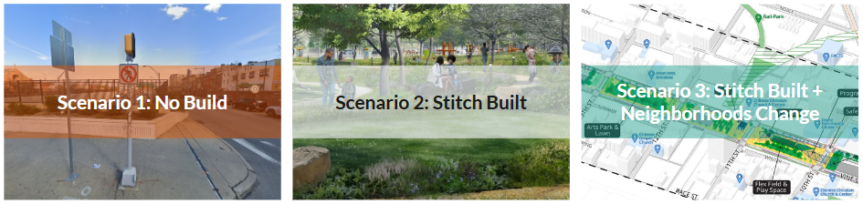

## 1.2 Study Area

```r
Philly_blockgroup <- st_read("Dataset/Philly_blockgroup/Philly_blockgroup.shp") %>%
  st_transform('EPSG:2272')

# philly bounds
philly_bounds <- st_union(Philly_blockgroup)

studyarea <- st_read("Dataset/studyarea/StudyArea.shp") %>%
  st_transform('EPSG:2272')

studyarea_blockgroup <- st_read("Dataset/studyarea/StudyArea_blockgroup_tract.shp") %>%
  st_transform('EPSG:2272')

studyarea_north <- st_read("Dataset/studyarea-sub/studyarea_north.shp") %>%
  st_transform('EPSG:2272')

studyarea_south <- st_read("Dataset/studyarea-sub/studyarea_south.shp") %>%
  st_transform('EPSG:2272')

I_676 <- st_read("Dataset/Highways/I_676.shp") %>%
  st_transform('EPSG:2272')

discontinuity <- st_read("Dataset/studyarea-sub/discontinuity.shp") %>%
  st_transform('EPSG:2272')

Chinatown_Stitch <- st_read("Dataset/Chinatown_Stitch/Chinatown_Stitch.shp") %>%
  st_transform('EPSG:2272')

property_original <- st_read("Dataset/original_property_studyarea.geojson") %>%
  st_transform('EPSG:2272')

property_north <- property_original %>%
  st_intersection(studyarea_north)

property_south <- property_original %>%
  st_intersection(studyarea_south)

# philly hydrology for mapping (bounded by philly_bounds; source: https://opendataphilly.org/datasets/hydrology/)
hydro <- st_read("https://services.arcgis.com/fLeGjb7u4uXqeF9q/arcgis/rest/services/Hydrographic_Features_Poly/FeatureServer/1/query?outFields=*&where=1%3D1&f=geojson") %>%
    st_transform(crs = 'EPSG:2272') %>%
  st_intersection(philly_bounds)

philly_highways <- st_read("Dataset/Highways/Casestudy_Highways.shp") %>%
  st_transform('EPSG:2272')

# cleaned and feature engineered property data for study area
property_studyarea_FE <- st_read("Dataset/property_CT_FE.geojson")
```

Three study areas are used in the analysis to reveal the effects of I-676 on the land market of the Chinatown region.

- **Referable study area (Philadelphia):** to analyse the impact of different highways on the surrounding land markets in the context of the city.
- **Main study area (10 block groups):** to figure out the correlation between I-676 and property sales price and make future predictions based on three potential scenarios.
- **Compared study area (north and south sides):** to investigate the different situations of the Chinatown region under the construction of I-676.

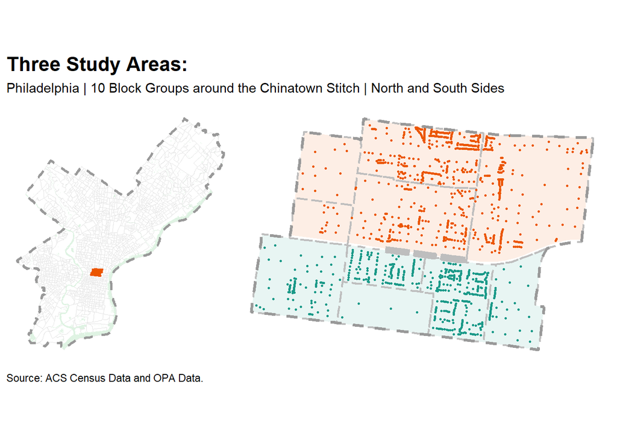

```r
StudyArea_plot1 <- ggplot() +
  geom_sf(data = Philly_blockgroup, fill = "transparent", color = "grey90", linewidth = .2) +
  geom_sf(data = studyarea, fill = "#eb5600", color = "#eb5600") +
  geom_sf(data = hydro, fill = "#DFF3E3", color = "transparent") +
  geom_sf(data = philly_bounds, fill = "transparent", color = "grey60", linewidth = 1, linetype = "dashed") +
  theme_void() +
  labs(title = "Three Study Areas:",
       subtitle = "Philadelphia | 10 Block Groups around the Chinatown Stitch | North and South Sides",
       caption = "Source: ACS Census Data and OPA Data.") +
  theme(plot.title = element_text(size = 16, face = "bold",margin = margin(b = 6)),
        plot.subtitle = element_text(margin = margin(b = 10)),
        plot.caption = element_text(hjust = 0, margin = margin(t = 10)))

StudyArea_plot2 <- ggplot() +
  geom_sf(data = studyarea_north, fill = alpha("#eb5600", .1), color = "transparent") +
  geom_sf(data = studyarea_south, fill = alpha("#1a9988", .1), color = "transparent") +
  # geom_sf(data = discontinuity, fill = "black", color = "transparent") +
  geom_sf(data = Chinatown_Stitch, fill = "grey", color = "transparent", linetype = "dashed", linewidth = 1) +
  geom_sf(data = studyarea_blockgroup, fill = "transparent", color = "grey", linewidth = .8, linetype = "dashed") +
  geom_sf(data = property_north, color = "#eb5600", size = .6) +
  geom_sf(data = property_south, color = "#1a9988", size = .6) +
  geom_sf(data = studyarea, fill = "transparent", color = "grey60", linewidth = 1.2, linetype = "dashed") +
  theme_void()

StudyArea_plot1 | StudyArea_plot2
```

```r
studyarea_4326 <- st_transform(studyarea, crs = 4326)
bbox <- as.list(st_bbox(studyarea_4326))

ChinatownStitch_4326 <- st_read("Dataset/Chinatown_Stitch/Chinatown_Stitch.shp") %>%
  st_transform('EPSG:4326')

I676_4326 <- st_transform(I_676, crs = 4326)

landuse_4326 <- st_read("Dataset/landuse_clip/Land_Use_ClipLayer.shp") %>%
  st_transform('EPSG:4326')

landuse_4326_plot <- landuse_4326 %>%
  filter(C_DIG2DESC != 51 & C_DIG2DESC != 71)

landuse_park_ing <- landuse_4326 %>%
  filter(OBJECTID_1 == 514214)

park_4326 <- st_read("Dataset/ParksModified/Parks_within_1km.shp") %>%
  st_transform('EPSG:4326')

# nhoods_4326 <-
#   st_read("DataWrangling/akidata/philadelphia-neighborhoods.geojson") %>%
#   # st_read("akidata/philadelphia-neighborhoods.geojson") %>%
#   st_transform('EPSG:4326')

Chinatown_Callowhill <- nhoods_4326 %>%
  filter(NAME %in% c("CHINATOWN", "CALLOWHILL"))
```

In the vision of **a city park** in the future, the Chinatown Stitch will bring vitality to local residents and visitors along with other green spaces. Connected with the Stitch, the **Rail Park** in the north (Callowhill neighborhood) is still in construction and will make an impact years later. With a foundation of **cultural and commercial resources**, the southern part (Chinatown neighborhood) will provide services to the surrounding area, including the city center of Philadelphia.

[interactive chart not shown]

[figure not shown]

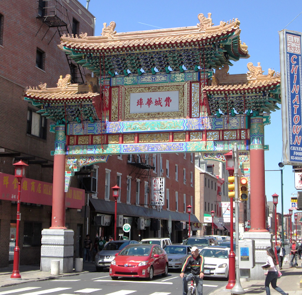

```r
UseCase <- leaflet() %>%
  addProviderTiles(providers$CartoDB.Positron) %>%
  addPolygons(data = studyarea_4326,
              color = "black",       # Black border
              weight = 4,            # Border thickness
              dashArray = "8,12",     # Dashed line pattern (5px on, 5px off)
              fill = FALSE) %>%
    addPolygons(data = landuse_4326_plot,
              color = "grey",
              weight = 0.8,
              fillColor = "#DFF3E3",
              fillOpacity = 0.4) %>%
  addPolygons(data = Chinatown_Callowhill,
              color = "#eb5600",
              weight = 1,
              opacity = 0.5,
              dashArray = "5,5",
              fillColor = "#eb5600",
              fillOpacity = 0.1) %>%
  addPolygons(data = park_4326,
              color = "#1a9988",
              weight = 1,
              fillOpacity = 0.6,
              fillColor = "#1a9988") %>%
  addPolygons(data = landuse_park_ing,
              color = "#1a9988",
              weight = 2,
              opacity = 0.8,
              fill = FALSE) %>%
  addPolylines(data = I676_4326,
               color = "#eb5600",
               opacity = 1,
               weight = 2) %>%
  addPolygons(data = ChinatownStitch_4326,
              color = "#eb5600",
              weight = 2,
              opacity = 1,
              fillColor = "#1a9988",
              fillOpacity = 0.8
              # fill = alpha("#1a9988", 0.5)
              ) %>%
  fitBounds(
    lng1 = bbox$xmin,
    lat1 = bbox$ymin,
    lng2 = bbox$xmax,
    lat2 = bbox$ymax
  )

div(class = "center-leaflet", UseCase)
```

Callowhill

Chinatown

## 1.3 Methodology

To achieve the goal of **a data-rich story map**, the methodology is structured around **a robust model construction process**. By incorporating illustrative data visualizations throughout the data analysis, the story map features engaging maps and compelling narratives.

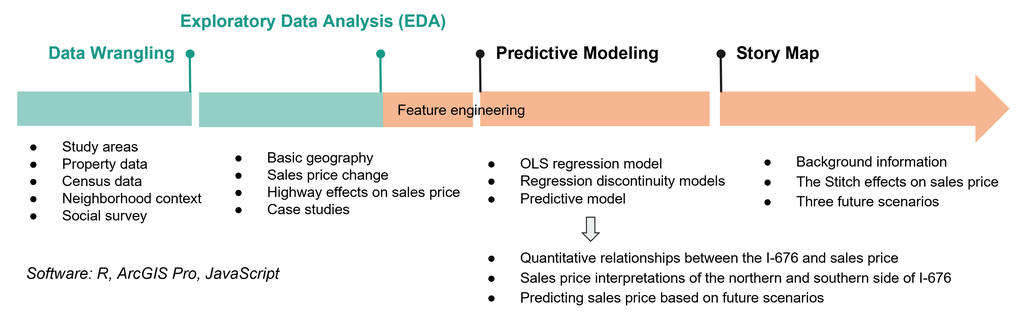

# 2 Data Wrangling

## 2.1 Property Data

- [Philadelphia Properties and Assessment History](https://opendataphilly.org/datasets/philadelphia-properties-and-assessment-history/)
- [Land use 2023](https://opendataphilly.org/datasets/land-use/)

```r
# property <- st_read("DataWrangling/akidata/opa_properties_public.geojson") %>%
#   st_transform('EPSG:2272')
#
# property_studyarea <- st_intersection(property, studyarea)
#
# st_write(property_studyarea %>% st_transform('EPSG:3857'), "Dataset/original_property_studyarea.geojson", driver = "GeoJSON")

property_studyarea <- st_read("Dataset/original_property_studyarea.geojson") %>%
  st_transform('EPSG: 2272')

landuse <- st_read("Dataset/landuse_clip/Land_Use_ClipLayer.shp") %>%
  st_transform('EPSG:2272')

landuse_rename <- landuse %>%
  mutate(landuse =
           case_when(
    C_DIG2DESC == 11 ~ "Residential Low",
    C_DIG2DESC == 12 ~ "Residential Medium",
    C_DIG2DESC == 13 ~ "Residential High",
    C_DIG2DESC == 21 ~ "Commercial Consumer",
    C_DIG2DESC == 22 ~ "Commercial Business/Professional",
    C_DIG2DESC == 23 ~ "Commercial Mixed Residential",
    C_DIG2DESC == 31 ~ "Industrial",
    C_DIG2DESC == 41 ~ "Civic/Institution",
    C_DIG2DESC == 51 ~ "Transportation",
    C_DIG2DESC == 61 ~ "Culture/Amusement",
    C_DIG2DESC == 62 ~ "Active Recreation",
    C_DIG2DESC == 71 ~ "Park/Open Space",
    C_DIG2DESC == 72 ~ "Cemetery",
    C_DIG2DESC == 81 ~ "Water",
    C_DIG2DESC == 91 ~ "Vacant",
    C_DIG2DESC == 92 ~ "Other/Unknown"
  ))

# philly properties (from Sijia)
# from the last 5 years, inflation-adjusted prices, total area > 100 sq ft, prices > 30,000, outliers above 5 SD from the mean were removed
# philly_properties <- st_read("akidata/property_philly_250318.geojson")
```

## 2.2 Census Data

## 2.3 Neighborhood Context

- [PPR Properties](https://opendataphilly.org/datasets/ppr-properties/)
- [Neighborhoods](https://opendataphilly.org/datasets/philadelphia-neighborhoods/)
- [Trolley Stations](https://hub.arcgis.com/datasets/dd2afb618d804100867dfe0669383159_0/explore?location=39.956470%2C-75.160382%2C14.19)
- [Highspeed Stations](https://hub.arcgis.com/datasets/af52d74b872045d0abb4a6bbbb249453_0/explore?location=39.955164%2C-75.153952%2C14.43)
- [Bike Network](https://opendataphilly.org/datasets/bike-network/)
- [311 Requests](https://opendataphilly.org/datasets/311-service-and-information-requests/)

```r
nhoods <-
  st_read("Dataset/DataWrangle/philadelphia-neighborhoods.geojson") %>%
  st_transform('EPSG:2272')

park <- st_read("Dataset/ParksModified/Parks_within_1km.shp") %>%
  st_transform('EPSG:2272')

# philly park data (https://opendataphilly.org/datasets/ppr-properties/)
philly_parks <- st_read("https://opendata.arcgis.com/datasets/d52445160ab14380a673e5849203eb64_0.geojson") %>%
  st_transform(crs = 'EPSG:2272') %>%
  st_intersection(philly_bounds)

metro <-
  st_read("https://opendata.arcgis.com/api/v3/datasets/af52d74b872045d0abb4a6bbbb249453_0/downloads/data?format=geojson&spatialRefId=4326") %>%
  st_transform('EPSG:2272') %>%
  mutate(Type = "metro")

city_hall <- metro[metro$Station == 'City Hall', 6]

trolley <-
    st_read("https://opendata.arcgis.com/api/v3/datasets/dd2afb618d804100867dfe0669383159_0/downloads/data?format=geojson&spatialRefId=4326") %>%
  st_transform('EPSG:2272')

trolley_renamed <- trolley %>%
  rename(Station = StopName,
         Route = LineAbbr,
         Longitude = Lon,
         Latitude = Lat) %>%
  mutate(Type = "trolley")

# Combine both datasets into one
transit <- bind_rows(metro, trolley_renamed)

school <-
  st_read("https://opendata.arcgis.com/datasets/d46a7e59e2c246c891fbee778759717e_0.geojson") %>%
  st_transform('EPSG:2272')

hospital <-
  st_read("Dataset/DataWrangle/DOH_Hospitals202311.geojson") %>%
  st_transform('EPSG:2272') %>%
  st_filter(st_union(Philly_blockgroup))

water <-
  st_read("https://services.arcgis.com/fLeGjb7u4uXqeF9q/arcgis/rest/services/Hydrographic_Features_Poly/FeatureServer/1/query?outFields=*&where=1%3D1&f=geojson") %>%
  st_transform('EPSG:2272')

bike_network <-
  st_read("Dataset/DataWrangle/Bike_Network.geojson") %>%
  st_transform('EPSG:2272')

phillyCrimes <-
  st_read("Dataset/DataWrangle/phillyCrimes.geojson") %>%
  st_transform('EPSG:2272')

# LPSS_PER1000: Number of low-produce supply stores per 1,000 people
# HPSS_PER1000: Number of high-produce supply stores per 1,000 people
retail <-
  st_read("https://opendata.arcgis.com/datasets/53b8a1c653a74c92b2de23a5d7bf04a0_0.geojson") %>%
  st_transform('EPSG:2272')
```

```r
calculate_nearest_distance <- function(set_points, other_layer) {
  nearest_idx <- st_nearest_feature(set_points, other_layer)
  st_distance(set_points, other_layer[nearest_idx, ], by_element = TRUE) %>% as.numeric()
}

Luming_property <- property_studyarea %>%
  dplyr::select(objectid, geometry, sale_price) %>%
  rename(orig_objectid = objectid)

Luming_property <- Luming_property %>%
  mutate(distance_to_city_hall = st_distance(., city_hall) %>% as.numeric()) %>%
  mutate(
    distance_to_nearest_transit = calculate_nearest_distance(geometry, transit),
    distance_to_nearest_hospital = calculate_nearest_distance(geometry, hospital),
    distance_to_nearest_school = calculate_nearest_distance(geometry, school),
    distance_to_nearest_park = calculate_nearest_distance(geometry, park),
    distance_to_nearest_water = calculate_nearest_distance(geometry, water),
    distance_to_nearest_bikelane = calculate_nearest_distance(geometry, bike_network),
    distance_to_I676 = calculate_nearest_distance(geometry, I_676)
  ) %>%
  st_join(nhoods["NAME"], left = TRUE) %>%
  rename(nhoods_name = NAME) %>%
  st_join(landuse_rename["landuse"], left = TRUE) %>%
  st_join(retail[, c("LPSS_PER1000", "HPSS_PER1000")], left = TRUE)

Luming_property <- Luming_property %>%
    mutate(
      crime_nn1 = nn_function(st_coordinates(Luming_property),
                              st_coordinates(phillyCrimes), k = 1),

      crime_nn2 = nn_function(st_coordinates(Luming_property),
                              st_coordinates(phillyCrimes), k = 2),

      crime_nn3 = nn_function(st_coordinates(Luming_property),
                              st_coordinates(phillyCrimes), k = 3),

      crime_nn4 = nn_function(st_coordinates(Luming_property),
                              st_coordinates(phillyCrimes), k = 4),

      crime_nn5 = nn_function(st_coordinates(Luming_property),
                              st_coordinates(phillyCrimes), k = 5))
```

## 2.4 Social Survey

## 2.5 POI Data

# 3 Highway Effects Analysis

## 3.1 Qualitative Research

```r
# property_EDA <- st_read("Dataset/property_sijia_eda.geojson") %>%
#   st_transform('EPSG:2272')
#
# property_EDA_update <- property_EDA %>%
#   dplyr::select(-sale_price.y) %>%
#   rename(sale_price = sale_price.x) %>%
#   mutate(log_sale_price = ifelse(!is.na(sale_price) & sale_price == 0,
#                                  log(sale_price + 1),
#                                  log(sale_price)))
#
# property_EDA_update <-
#   rbind(
#     property_EDA_update %>% st_intersection(studyarea_north["geometry"]) %>%
#       mutate(I676 = "north"),
#     property_EDA_update %>% st_intersection(studyarea_south["geometry"]) %>%
#       mutate(I676 = "south")
#   )

# making sure philly_properties has the same columns as property_EDA_update
# this dataset will be used for the Study Area Scale analysis (I-676 effects + Discontinuity effects)
# also, only keep properties within the study area
# names_toadd <- names(property_EDA_update)[which(!(names(property_EDA_update) %in% names(philly_properties)))]
#
# properties_i676 <- philly_properties %>%
#   filter(objectid %in% property_studyarea$objectid) %>% # this limits what was formally 2394 properties in the study area, to only 94 properties..... definitely needs to be checked
#   mutate(objectid = as.character(objectid)) %>%
#   left_join(property_EDA_update %>%
#               select(c(names_toadd, objectid)) %>%
#               st_drop_geometry(),
#             by = "objectid")

# checking that this worked
# all(names(property_EDA_update) %in% names(properties_i676)) # TRUE, period!
```

## 3.2 Philadelphia Scale Analysis

Our **Philadelphia Scale Analysis** looks at properties (of all kinds, not limited to housing properties) within 500 m of Philadelphia’s main highways – I-95 on the East, I-76 on the West, US-1 in the North, and I-676 through the city. We saw the following trends in property prices.

```r
# create 500m buffer around philly highways
buff500 <- 500 * 3.28084
hiway_500buff <- st_union(st_buffer(philly_highways, buff500))

# read in pre-saved file
prop500 <- st_read("Dataset/phl_properties_dist2highway/philly_prop500_dst2hghwy_250421.geojson") %>%
  mutate(closest_highway = factor(closest_highway, levels = c("US-1", "I-76", "I-676", "I-95")))
```

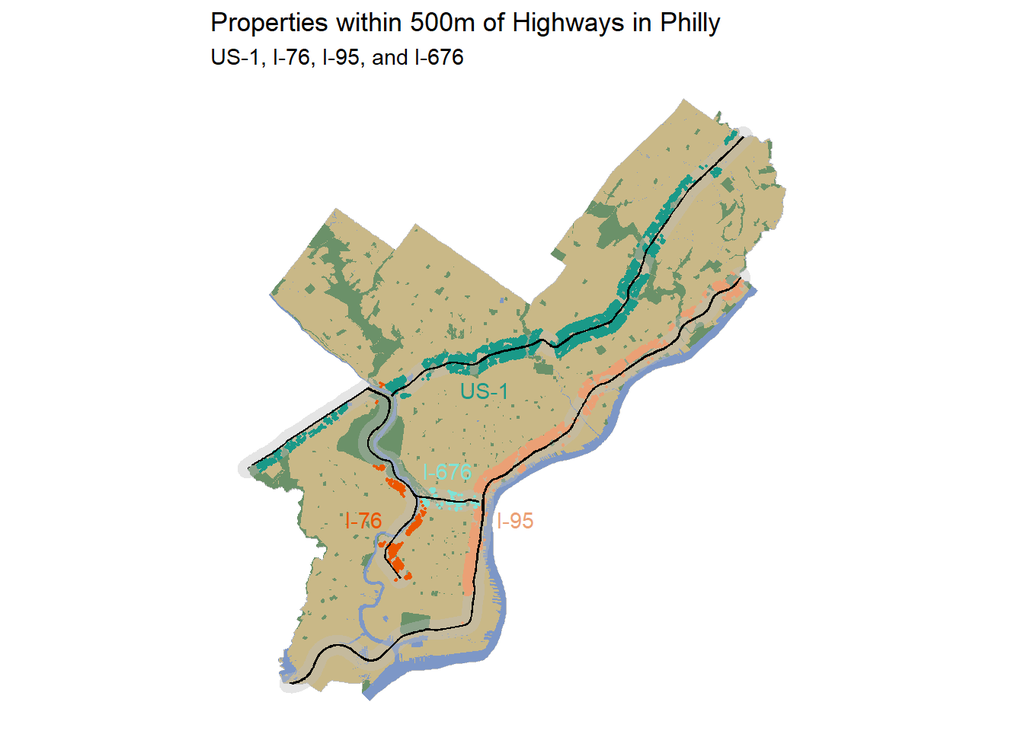

```r
# map of properties within 500m of highway cored by which highway they're closest to
ggplot() +
  geom_sf(data = philly_bounds, fill = "#c9b887", color = "grey") +
  geom_sf(data = hydro, fill = "#7d97c7", color = "transparent") +
  geom_sf(data = philly_parks, fill = "#6b9169", color = "transparent") +
  geom_sf(data = hiway_500buff,
          color = "transparent", fill = "grey", alpha = 0.4) +
  geom_sf(data = prop500,
          aes(color = closest_highway), size = 0.3,
          show.legend = F) +
  geom_sf(data = philly_highways,
          color = "black") +

  # add custom colors
  scale_color_manual(values = c("US-1" = "#1a9988",
                                "I-76" = "#eb5600",
                                "I-95" = "#eba075",
                                "I-676" = "#7fe3d6")) +
  # labels for highway names
  geom_text(aes(label = "US-1",
                x = 2700000,
                y = 256453.2),
            color = "#1a9988") +
  geom_text(aes(label = "I-76",
                x = 2680000,
                y = 235000),
            color = "#eb5600") +
  geom_text(aes(label = "I-95",
                x = 2705200,
                y = 235000),
            color = "#eba075") +
  geom_text(aes(label = "I-676",
                x = 2694000,
                y = 243000),
            color = "#7fe3d6") +

  labs(title = "Properties within 500m of Highways in Philly",
       subtitle = "US-1, I-76, I-95, and I-676",
       color = "Closest Highway") +
  theme_void()
```

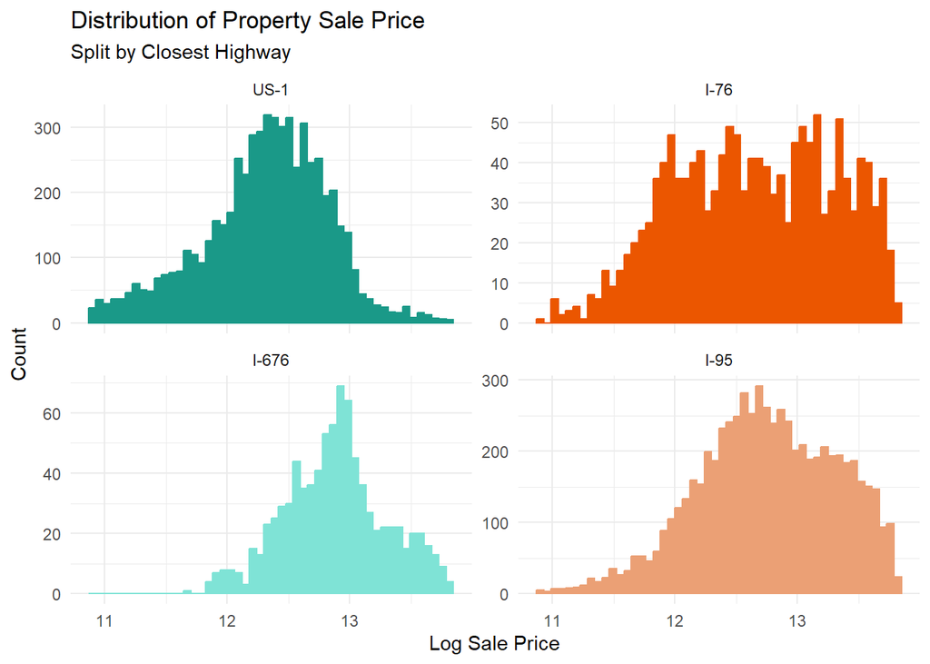

```r
prop500_faceted <-
  ggplot(data = prop500,
         aes(x = log_price, color = closest_highway, fill = closest_highway)) +
  geom_histogram(bins = 50, show.legend = F) +
  facet_wrap(~closest_highway, scales = "free_y") +
  scale_color_manual(values = c("US-1" = "#1a9988",
                                "I-76" = "#eb5600",
                                "I-95" = "#eba075",
                                "I-676" = "#7fe3d6")) +
  scale_fill_manual(values = c("US-1" = "#1a9988",
                               "I-76" = "#eb5600",
                               "I-95" = "#eba075",
                               "I-676" = "#7fe3d6")) +
  labs(title = "Distribution of Property Sale Price",
       subtitle = "Split by Closest Highway",
       x = "Log Sale Price",
       y = "Count") +
  theme_minimal()

prop500_faceted
```

```r
# median sale prices to talk about in the text
med_price_us1 <- round(median(prop500 %>%
                          filter(closest_highway == "US-1") %>%
                          pull(adj_sale_price)))

med_price_i76 <- round(median(prop500 %>%
                          filter(closest_highway == "I-76") %>%
                          pull(adj_sale_price)))

med_price_i95 <- round(median(prop500 %>%
                          filter(closest_highway == "I-95") %>%
                          pull(adj_sale_price)))

med_price_676 <- round(median(prop500 %>%
                          filter(closest_highway == "I-676") %>%
                          pull(adj_sale_price)))

# count of properties included in analysis
prop_count <- prop500 %>%
  st_drop_geometry() %>%
  group_by(closest_highway) %>%
  summarise(count = n())

prop_count_676 <- prop_count %>%
  filter(grepl("676", closest_highway)) %>%
  pull(count)

prop_count_us1 <- prop_count %>%
  filter(grepl("US", closest_highway)) %>%
  pull(count)

prop_count_i76 <- prop_count %>%
  filter(grepl("-76", closest_highway)) %>%
  pull(count)

prop_count_i95 <- prop_count %>%
  filter(grepl("95", closest_highway)) %>%
  pull(count)
```

14,751 total properties were included in this analysis. We see that the distribution of log sale prices of properties within 500m of highways in Philadelphia generally follow a normal distribution.

Though there aren’t as many properties near I-676 (863 properties) as there are near the other highways, they are most expensive group with a median property price of **$397,155**.

Properties near I-95 and I-76 are among a similar range of prices with median property prices being **$345,762** and **$316,000**, respectively, though there are almost five times as many properties near I-95 compared to I-76 (6,547 and 1,410 properties around I-95 and I-76, respectively).

Finally, there are many properties within 500m of US-1 (5,931 properties), but the median property price was lowest compared to other highways at **$234,283**.

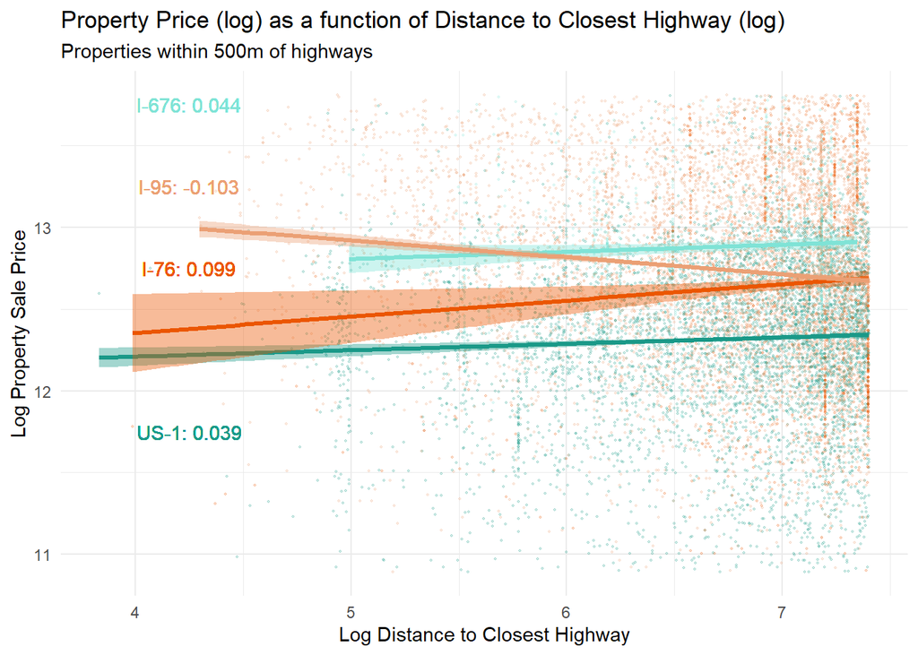

```r
# models + beta coefficients
coef_us1 <- round(
  summary(
    lm(log_price ~ log_dist_to_closest_highway,
       data = prop500 %>%
         filter(grepl("US", closest_highway)))
    )$coefficients[2,1], 3) # *** p < 0.001

coef_i76 <- round(
  summary(
    lm(log_price ~ log_dist_to_closest_highway,
       data = prop500 %>%
         filter(grepl("-76", closest_highway)))
    )$coefficients[2,1], 3) # ** p < 0.05

coef_i95 <- round(
  summary(
    lm(log_price ~ log_dist_to_closest_highway,
       data = prop500 %>%
         filter(grepl("95", closest_highway)))
    )$coefficients[2,1], 3) # *** p < 0.001

coef_i676 <- round(
  summary(
    lm(log_price ~ log_dist_to_closest_highway,
       data = prop500 %>%
         filter(grepl("676", closest_highway)))
    )$coefficients[2,1], 3) # not statistically significant, p = 0.0693

scatter_4highways <-
  ggplot(data = prop500,
       aes(x = log_dist_to_closest_highway, y = log_price,
           color = closest_highway, fill = closest_highway)) +
  geom_point(alpha = .2, size = 0.3, show.legend = F) +
  geom_smooth(method = "lm", size = 1.2, show.legend = F) +
  scale_color_manual(values = c("US-1" = "#1a9988",
                                "I-76" = "#eb5600",
                                "I-95" = "#eba075",
                                "I-676" = "#7fe3d6")) +
  scale_fill_manual(values = c("US-1" = "#1a9988",
                               "I-76" = "#eb5600",
                               "I-95" = "#eba075",
                               "I-676" = "#7fe3d6")) +
  geom_text(aes(label = paste("US-1:", coef_us1),
                x = 4.25,
                y = 11.75),
            color = "#1a9988",
            show.legend = F) +
  geom_text(aes(label = paste("I-76:", coef_i76),
                x = 4.25,
                y = 12.75),
            color = "#eb5600",
            show.legend = F) +
  geom_text(aes(label = paste("I-95:", coef_i95),
                x = 4.25,
                y = 13.25),
            color = "#eba075",
            show.legend = F) +
  geom_text(aes(label = paste("I-676:", coef_i676),
                x = 4.25,
                y = 13.75),
            color = "#7fe3d6",
            show.legend = F) +
  labs(title = "Property Price (log) as a function of Distance to Closest Highway (log)",
       subtitle = "Properties within 500m of highways",
       x = "Log Distance to Closest Highway",
       y = "Log Property Sale Price") +
  theme_minimal()

scatter_4highways
```

The scatter plot above shows the relationship between distance to highway and property price along with the regression coefficients for each highway. We observe that without controlling for anything else, property prices generally increase (albeit by very little) as we move away from a highway which tracks with our literature review of highway effects on property prices.

When predicting property price, the beta coefficient for log distance to highway is 0.044, 0.099, and 0.039 for I-676, I-76, and US-1, respectively (note that the though the beta coefficients were significant with p < 0.01 for I-76 and US-1, it was not statistically significant for I-676 with a p = 0.069).

For every 1% increase in distance from I-676, property price increases by 0.04%. In more understandable terms, this means that if a property that is $100,000 is 50m away from the highway, we can expect a similar property a block further from the highway to be about **$6290 more expensive** (assuming a block is about 200m). For every 1% increase in distance from I-76, property price increases by 0.1%, meaning a property that is $100,000 is 50m away from the highway would be about **$14711 more expensive** if it were a block further from the highway. For every 1% increase in distance from US-1, property price increases by 0.04%, meaning a property that is $100,000 is 50m away from the highway would be about **$5555 more expensive** if it were a block further from the highway.

We now zoom into our **study area** to further understand highway effects in our region of interest.

### 3.2.1 same interpretation but with 100m instead of 200m

For every 1% increase in distance from I-676, property price increases by 0.04%. In more understandable terms, this means that if a property that is $100,000 is 50m away from the highway, we can expect a similar property a block further from the highway to be about **$3097 more expensive** (assuming a block is about 100m). For every 1% increase in distance from I-76, property price increases by 0.1%, meaning a property that is $100,000 is 50m away from the highway would be about **$7103 more expensive** if it were a block further from the highway. For every 1% increase in distance from US-1, property price increases by 0.04%, meaning a property that is $100,000 is 50m away from the highway would be about **$2740 more expensive** if it were a block further from the highway.

The exception here is for properties within 500m of I-95, where the beta coefficient for log distance to highway is -0.103 (p < 0.001). For every 1% increase in distance from I-95, property price decreases by 0.1%. In more understandable terms, this means that if a property that is $100,000 is 50m away from the highway, we can expect a similar property a block further from the highway to be about **$6891 less expensive**.

### 3.2.2 I-95 Exploration

Taking a look at the properties near I-95 to see why we see a different relationship between distance to highway and property price here.

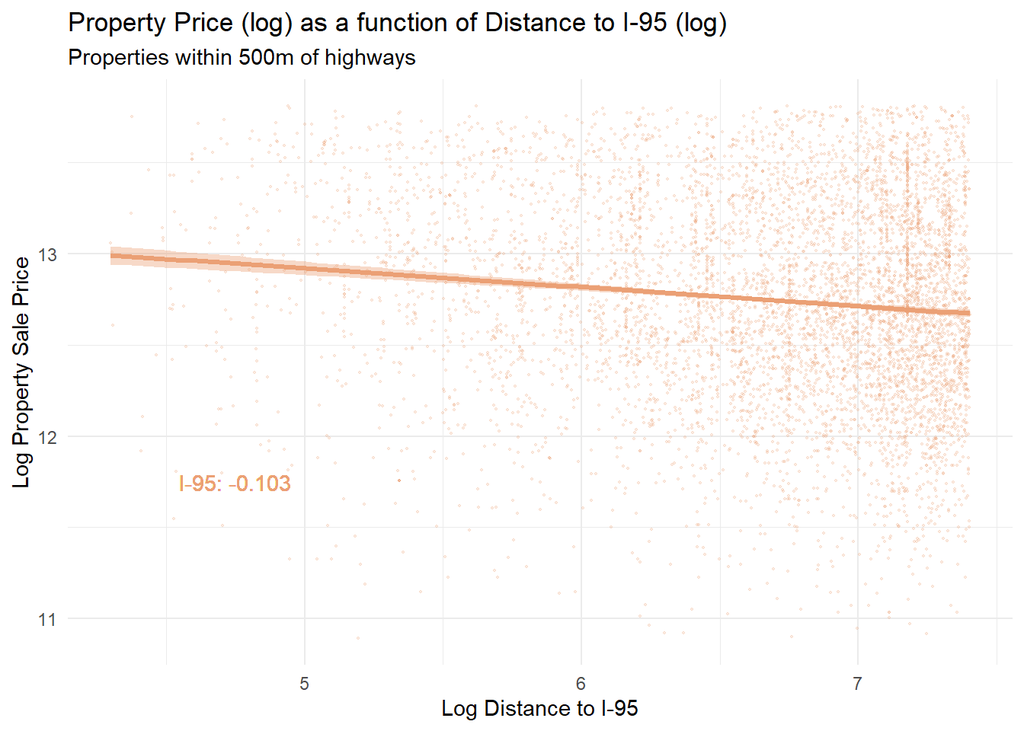

```r
# trying to figure out why we see a negative relationship between distance to highway and property price by I-95
i95_500 <- prop500 %>%
  filter(closest_highway == "I-95") # 6547 total properties

# scatter plot to see relationship
i95_scatter <- ggplot(i95_500,
                      aes(x = log_dist_to_closest_highway, y = log_price)) +
  geom_point(color = "#eba075", alpha = .2, size = 0.3, show.legend = F) +
  geom_smooth(color = "#eba075", fill = "#eba075", method = "lm", size = 1.2, show.legend = F) +
  geom_text(aes(label = paste("I-95:", coef_i95),
                x = 4.75,
                y = 11.75),
            color = "#eba075",
            show.legend = F) +
  labs(title = "Property Price (log) as a function of Distance to I-95 (log)",
       subtitle = "Properties within 500m of highways",
       x = "Log Distance to I-95",
       y = "Log Property Sale Price") +
  theme_minimal()
i95_scatter
```

### 3.2.3 Philly Scale Analysis (Residential Properties only)

Now, we conduct the same analyses to explore the relationship between **distance to highway** and **property prices** for residential properties only (excluding residential garages and vacant lots). We saw the following trends in property prices.

```r
# properties within 500 m of highway that are specifically housing related (excluding residential garages and vacant lands)
prop500_res <- prop500 %>%
  filter(grepl("APARTMENTS|MIXED USE|MULTI FAMILY|SINGLE FAMILY", category_code_description))
# 98.1% of the properties 500 m within highways are residential.
```

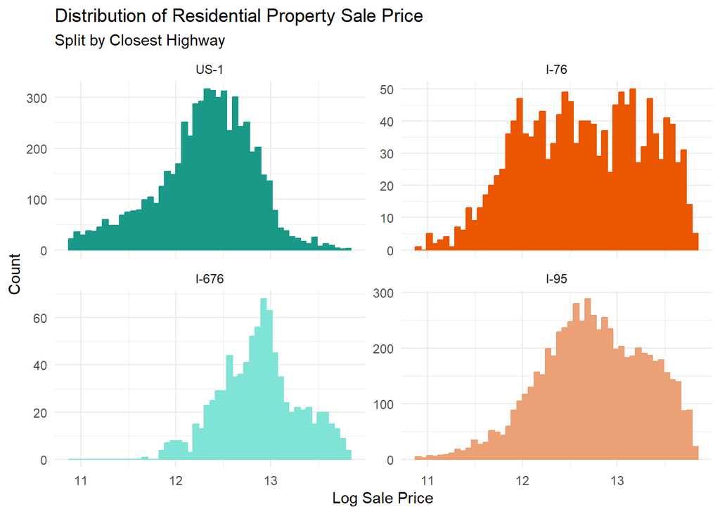

```r
prop500_res_faceted <-
  ggplot(data = prop500_res,
         aes(x = log_price, color = closest_highway, fill = closest_highway)) +
  geom_histogram(bins = 50, show.legend = F) +
  facet_wrap(~closest_highway, scales = "free_y") +
  scale_color_manual(values = c("US-1" = "#1a9988",
                                "I-76" = "#eb5600",
                                "I-95" = "#eba075",
                                "I-676" = "#7fe3d6")) +
  scale_fill_manual(values = c("US-1" = "#1a9988",
                               "I-76" = "#eb5600",
                               "I-95" = "#eba075",
                               "I-676" = "#7fe3d6")) +
  labs(title = "Distribution of Residential Property Sale Price",
       subtitle = "Split by Closest Highway",
       x = "Log Sale Price",
       y = "Count") +
  theme_minimal()

prop500_res_faceted
```

```r
# this one is largely unchanged
```

```r
# median sale prices to talk about in the text
med_res_price_us1 <- round(median(prop500_res %>%
                          filter(closest_highway == "US-1") %>%
                          pull(adj_sale_price)))

med_res_price_i76 <- round(median(prop500_res %>%
                          filter(closest_highway == "I-76") %>%
                          pull(adj_sale_price)))

med_res_price_i95 <- round(median(prop500_res %>%
                          filter(closest_highway == "I-95") %>%
                          pull(adj_sale_price)))

med_res_price_676 <- round(median(prop500_res %>%
                          filter(closest_highway == "I-676") %>%
                          pull(adj_sale_price)))

# count of properties included in analysis
prop_res_count <- prop500_res %>%
  st_drop_geometry() %>%
  group_by(closest_highway) %>%
  summarise(count = n())

prop_res_count_676 <- prop_res_count %>%
  filter(grepl("676", closest_highway)) %>%
  pull(count)

prop_res_count_us1 <- prop_res_count %>%
  filter(grepl("US", closest_highway)) %>%
  pull(count)

prop_res_count_i76 <- prop_res_count %>%
  filter(grepl("-76", closest_highway)) %>%
  pull(count)

prop_res_count_i95 <- prop_res_count %>%
  filter(grepl("95", closest_highway)) %>%
  pull(count)
```

14,475 total properties were included in this analysis. We see that the distribution of log sale prices of properties within 500m of highways in Philadelphia generally follow a normal distribution.

Though there aren’t as many properties near I-676 (852 properties) as there are near the other highways, they are most expensive group with a median property price of **$393,263**.

Properties near I-95 and I-76 are among a similar range of prices with median property prices being **$343,238** and **$310,589**, respectively, though there are almost five times as many properties near I-95 compared to I-76 (6,395 and 1,382 properties around I-95 and I-76, respectively).

Finally, there are many properties within 500m of US-1 (5,846 properties), but the median property price was lowest compared to other highways at **$233,189**.

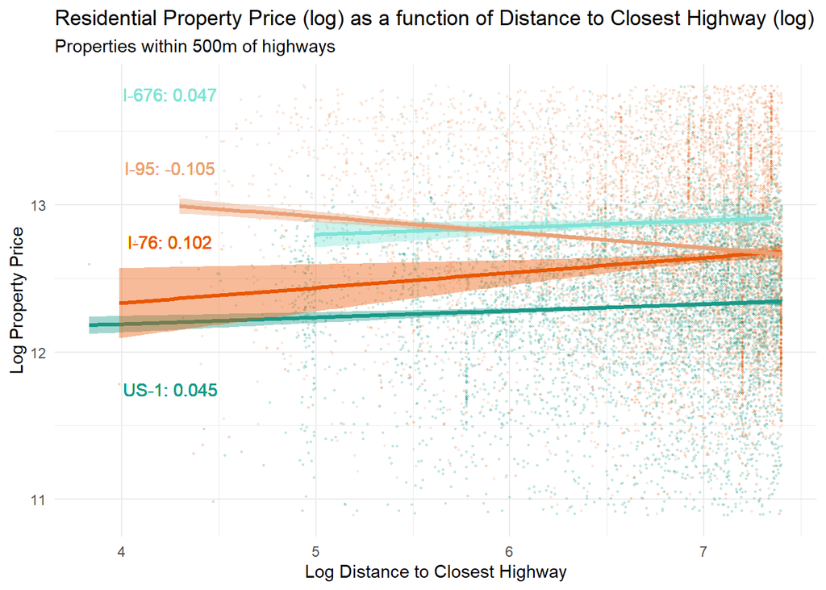

```r
# models + beta coefficients
coef_res_us1 <- round(
  summary(
    lm(log_price ~ log_dist_to_closest_highway,
       data = prop500_res %>%
         filter(grepl("US", closest_highway)))
    )$coefficients[2,1], 3) # *** p < 0.001

coef_res_i76 <- round(
  summary(
    lm(log_price ~ log_dist_to_closest_highway,
       data = prop500_res %>%
         filter(grepl("-76", closest_highway)))
    )$coefficients[2,1], 3) # ** p < 0.05

coef_res_i95 <- round(
  summary(
    lm(log_price ~ log_dist_to_closest_highway,
       data = prop500_res %>%
         filter(grepl("95", closest_highway)))
    )$coefficients[2,1], 3) # *** p < 0.001

coef_res_i676 <- round(
  summary(
    lm(log_price ~ log_dist_to_closest_highway,
       data = prop500_res %>%
         filter(grepl("676", closest_highway)))
    )$coefficients[2,1], 3) # not statistically significant, p = 0.0693

scatter_4highways_res <-
  ggplot(data = prop500_res,
       aes(x = log_dist_to_closest_highway, y = log_price,
           color = closest_highway, fill = closest_highway)) +
  geom_point(alpha = .2, size = 0.3, show.legend = F) +
  geom_smooth(method = "lm", size = 1.2, show.legend = F) +
  scale_color_manual(values = c("US-1" = "#1a9988",
                                "I-76" = "#eb5600",
                                "I-95" = "#eba075",
                                "I-676" = "#7fe3d6")) +
  scale_fill_manual(values = c("US-1" = "#1a9988",
                               "I-76" = "#eb5600",
                               "I-95" = "#eba075",
                               "I-676" = "#7fe3d6")) +
  geom_text(aes(label = paste("US-1:", coef_res_us1),
                x = 4.25,
                y = 11.75),
            color = "#1a9988",
            show.legend = F) +
  geom_text(aes(label = paste("I-76:", coef_res_i76),
                x = 4.25,
                y = 12.75),
            color = "#eb5600",
            show.legend = F) +
  geom_text(aes(label = paste("I-95:", coef_res_i95),
                x = 4.25,
                y = 13.25),
            color = "#eba075",
            show.legend = F) +
  geom_text(aes(label = paste("I-676:", coef_res_i676),
                x = 4.25,
                y = 13.75),
            color = "#7fe3d6",
            show.legend = F) +
  labs(title = "Residential Property Price (log) as a function of Distance to Closest Highway (log)",
       subtitle = "Properties within 500m of highways",
       x = "Log Distance to Closest Highway",
       y = "Log Property Price") +
  theme_minimal()

scatter_4highways_res
```

The scatter plot above shows the relationship between distance to highway and property price along with the regression coefficients for each highway. We observe that without controlling for anything else, property prices generally increase (albeit by very little) as we move away from a highway which tracks with our literature review of highway effects on property prices.

When predicting property price, the beta coefficient for log distance to highway is 0.047, 0.102, and 0.045 for I-676, I-76, and US-1, respectively (note that the though the beta coefficients were significant with p < 0.01 for I-76 and US-1, it was not statistically significant for I-676 with a p = 0.069).

For every 1% increase in distance from I-676, property price increases by 0.05%. In more understandable terms, this means that if a property that is $100,000 is 50m away from the highway, we can expect a similar property a block further from the highway to be about **$6733 more expensive** (assuming a block is about 200m). For every 1% increase in distance from I-76, property price increases by 0.1%, meaning a property that is $100,000 is 50m away from the highway would be about **$15189 more expensive** if it were a block further from the highway. For every 1% increase in distance from US-1, property price increases by 0.04%, meaning a property that is $100,000 is 50m away from the highway would be about **$6437 more expensive** if it were a block further from the highway.

The exception here is for properties within 500m of I-95, where the beta coefficient for log distance to highway is -0.105 (p < 0.001). For every 1% increase in distance from I-95, property price decreases by 0.1%. In more understandable terms, this means that if a property that is $100,000 is 50m away from the highway, we can expect a similar property a block further from the highway to be about **$13546 less expensive**.

We now zoom into our **study area** to further understand highway effects in our region of interest.

## 3.3 Study Region Scale Analysis

### 3.3.1 Basic Geography

```r
park_clipped <- st_intersection(park, studyarea)
park_valid <- st_make_valid(park)
transit_valid <- st_make_valid(transit)
city_hall_valid <- st_make_valid(city_hall)
school_valid <- st_make_valid(school)
water_valid <- st_make_valid(water)
bike_network_valid <- st_make_valid(bike_network)

studyarea_buffer <- st_buffer(studyarea, dist = 1000)

# Clip each dataset to the study area
recreation_clipped <- st_intersection(park, studyarea_buffer)
transit_clipped <- st_intersection(transit_valid, studyarea_buffer)
city_hall_clipped <- st_intersection(city_hall_valid, studyarea_buffer)
school_clipped <- st_intersection(school_valid, studyarea_buffer)
water_clipped <- st_intersection(water_valid, studyarea_buffer)
bike_network_clipped <- st_intersection(bike_network_valid, studyarea_buffer)
landuse_transportation <- landuse_rename[landuse_rename$landuse == "Transportation", ]

# property_vacant <- property_EDA %>%
#   filter(category_code_description %in% c("VACANT LAND","SINGLE FAMILY", "VACANT LAND - NON-RESIDENTIAL")) %>%
#   mutate(category_code_description = case_when(
#     category_code_description == "VACANT LAND - NON-RESIDENTIAL" ~ "VACANT LAND",
#     TRUE ~ category_code_description
#   ))
```

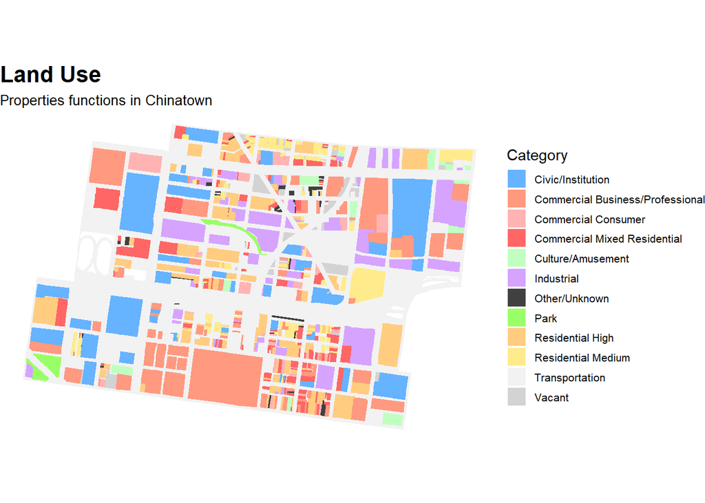

```r
landuse_colors <- c(
  "Residential Low" = "#FFFFB3",
  "Residential Medium" = "#FFEB8B",
  "Residential High" = "#FFCC80",
  "Commercial Consumer" = "#FFB3B3",
  "Commercial Business/Professional" = "#FF9980",
  "Commercial Mixed Residential" = "#FF6666",
  "Industrial" = "#D6A3FF",
  "Civic/Institution" = "#66B3FF",
  "Transportation" = "gray95",
  "Culture/Amusement" = "#C1FFC1",
  "Active Recreation" = "#66FFD9",
  "Park/Open Space" = "#99FF66",
  "Cemetery" = "#FF9999",
  "Water" = "#99CCFF",
  "Vacant" = "#D3D3D3",
  "Other/Unknown" = "gray25"
)

BasicGeo_plot1 <- ggplot(data = landuse_rename %>%
          filter(!is.na(landuse) & landuse != "Park/Open Space")) +
  geom_sf(aes(fill = landuse), color = NA) +
  geom_sf(data = park_clipped, aes(fill = "Park"), color = NA, alpha = 1) +  # Clipped park layer
  scale_fill_manual(values = c(landuse_colors, "Park" = "#99FF66"), na.value = "white") +
  labs(title = "Land Use",
       subtitle = "Properties functions in Chinatown",
       fill = "Category") +
  theme_void() +
  theme(legend.position = "right",
        plot.title = element_text(size = 16, face = "bold"),
        plot.subtitle = element_text(size = 10),
        legend.key.size = unit(0.5, "cm"),
        legend.text = element_text(size = 8))

BasicGeo_plot2 <- ggplot() +
  geom_sf(data = landuse, fill = "white", color = "gray90", size = 0.05) +
  geom_sf(data = recreation_clipped, aes(fill = "Park"), color = NA, alpha = 1) +
  geom_sf(data = landuse_transportation, aes(fill = "Transportation"), color = NA, alpha = 0.5) +
  geom_sf(data = transit_clipped, aes(color = "Transit"), size = 2) +
  geom_sf(data = school_clipped, aes(color = "School"), size = 2) +
  geom_sf(data = bike_network_clipped, aes(color = "Bike Network"), size = 1) +

  scale_color_manual(values = c("Transit" = "blue", "School" = "orange", "Bike Network" = "purple"), name = NULL) +
  scale_fill_manual(values = c("Park" = "green","Transportation" = "gray70"), name = NULL) +

  labs(
    title = "Amenities",
    subtitle = "<span style='color:orange;'>Schools</span>, <span style='color:blue;'>Transit Stations</span>, <span style='color:green;'>Parks</span>, and <span style='color:purple;'>Bike Lanes</span>"
  ) +
  theme_void() +
  theme(
    legend.position = "none",
    plot.title = element_text(size = 16, face = "bold"),
    plot.subtitle = element_markdown(size = 10, hjust = 0),
    legend.key.size = unit(0.5, "cm"),
    legend.text = element_text(size = 8)
  )

BasicGeo_plot3 <- ggplot() +
  geom_sf(data = landuse, fill = "white", color = "gray85", size = 0.05) +
  geom_sf(data = studyarea, fill = "transparent", color = "grey", linetype = "dashed", linewidth = 2) +
  geom_sf(data = discontinuity, fill = "#eb5600", color = "transparent") +
  geom_sf(data = Chinatown_Stitch, fill = "#1a9988", alpha = 0.8) +
  # geom_sf(data = property_vacant, aes(color = category_code_description), size = 1) +
  scale_colour_manual(values = c("black", "#B67352")) +
  labs(title="Potential Lands",
       subtitle = glue("<span style='color:#1a1a1a;'>Single Family & </span><span style='color:#B67352;'>Vacant Land</span>"),
       # caption = "Figure "
       ) +
  theme_void() +
  theme(legend.position = "none",
        plot.title = element_text(size = 16, face = "bold"),
        plot.subtitle = ggtext::element_markdown(size = 10))

BasicGeo_plot1
```

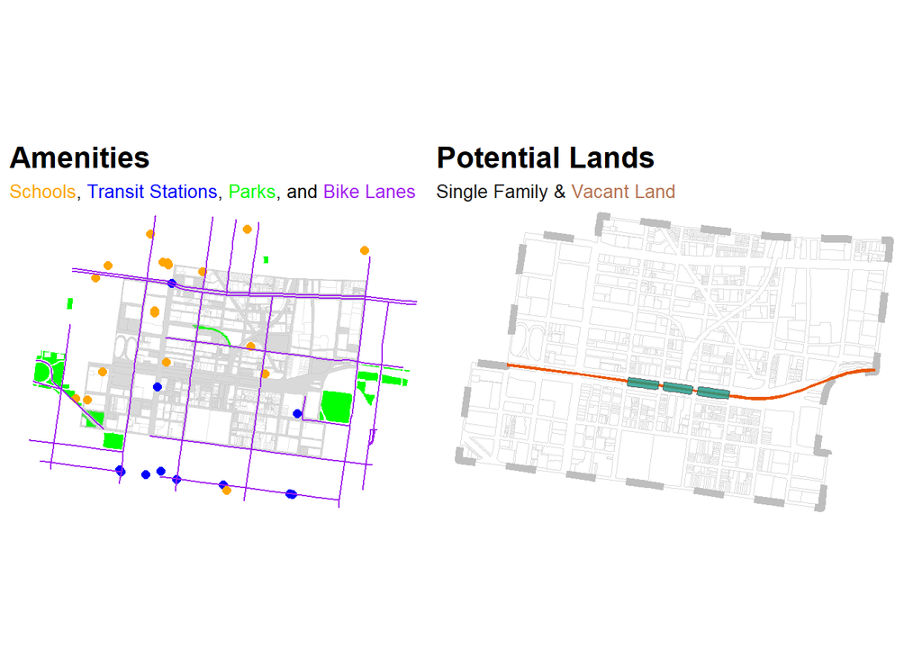

```r
BasicGeo_plot2 | BasicGeo_plot3
```

### 3.3.2 Sales Price Change

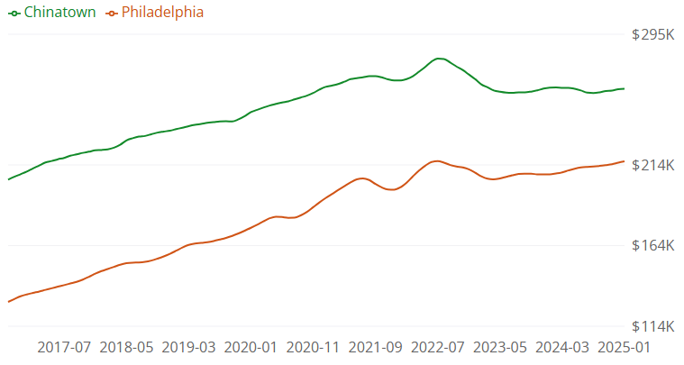

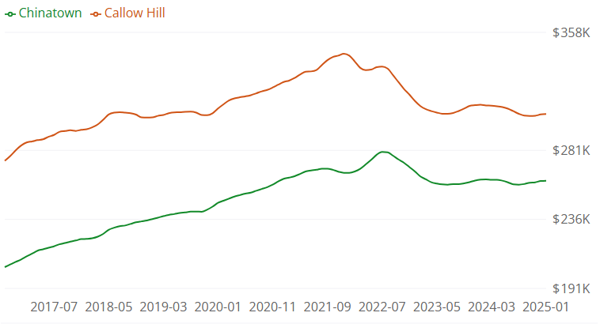

### 3.3.3 I-676 Effects

One of OTIS’s key interests is the effect of I-676 on property prices nearby. Here, we construct a relatively **simple linear model** with a few key predictors to look at the effect of I-676 on property prices while accounting for some control variables such as the square footage of the property, number of bathrooms, year built, zoning, and zip code among others.

For these analyses, we look at properties **within our study area**.

```r
# working with the newest philly_properties dataset where data was cleaned for our studyarea
property_studyarea_new <- st_read("Dataset/property_CT_FE.geojson") #1528 rows

# add features for simple linear regression
props_i676_tomodel <- property_studyarea_new %>%
  # filter() %>% # there are a couple properties with total area < 100; reduces dataset to 990 properties
  # some feature engineering
  mutate(residential = ifelse(category_code_description %in% c("APARTMENTS  > 4 UNITS",
                                                               "MIXED USE",
                                                               "MULTI FAMILY",
                                                               "SINGLE FAMILY",
                                                               "GARAGE - RESIDENTIAL"),
                              1, 0), # is this property residential? (including mixed)

         building_code_description_new = case_when(
           grepl("FITNESS CENTER|GOV'T MUNICIPAL/STATE/FEDERAL", building_code_description_new) ~ "MostExpensive",
           grepl("LIFE CARE FACILITY-ASSTD LVNG|CORRECTIONAL|MEDICAL OFFICE BLDNG|PARKING GARAGE/DECK|BOARDING/ROOMING HOSUE|MIXED - RES/COMM|SCHOOL|BANK|OFFICE BLDNG - Mid Rise|DET MIXED-COM/RES-BLT AS COM", building_code_description_new) ~ "MoreExpensive",
           grepl("RETAIL - * SINGLE OCCUPANCY|ROW MIXED-COM/RES-BLT AS COM|ROW MODERN|APARTMENTS - LOW RISE|HOTEL - HI RISE|OFFICE BLDNG - Low Rise|FUNERAL HOME|RESTAURANT|DOWNTOWN ROW TYPE-* SNGL OCCP|WAREHOUSE|TWIN CONTEMPORARY|CAR WASH - AUTOMATIC|RETAIL CONDO|MANUFACTURING/PROCESSING|LOFT (INDUSTRIAL)|APARTMENTS - MID RISE|RELIGIOUS", building_code_description_new) ~ "Average",
           .default = "LeastExpensive"
           ),
         building_code_description_new = factor(building_code_description_new),

         # all the other variables have been cleaned and feature engineered
) %>%
  select(   # only keep vars necessary for model
    adj_sale_price,
    log_price, distance_to_I676, log_dist_highway,
    residential,
    year_built, year_built_group,
    central_air, garage_spaces,
    number_of_bathrooms, number_of_bedrooms, total_area,
    exterior_condition, interior_condition, quality_grade,
    building_code_description_new, zoning_group,
    zip_code,
    I676_NS
  )
```

```r
getRMSE <- function(model_results) {
  # residual sum of squares
  rss <- c(crossprod(model_results$residuals))
  # Mean squared error:
  mse <- rss / length(model_results$residuals)
  # Root MSE:
  RMSE <- sqrt(mse)

  return(RMSE)
}
```

#### 3.3.3.1 Model Results

```r
# model with just distance to highway
model_i676 <- lm(log_price ~ log_dist_highway,
                 data = props_i676_tomodel)
# log_dist_highway  0.11110
# Multiple R-squared:  0.01228, Adjusted R-squared:  0.01163

model_i676_summary <- summary(model_i676)
model_i676_RMSE <- getRMSE(model_i676)

# create a clean table to show model results
model_i676_table <- data.frame(model_i676_summary$coefficients) %>%
  rename(p = `Pr...t..`) %>%
  select(Estimate, p) %>%
  mutate(Estimate = round(Estimate, 3),
         p = round(p, 3))
row.names(model_i676_table) <- c("Intercept", "Log Dist. to I-676")

model_i676_table %>%
  kbl(align = c("l", rep("c", 2)),
      caption = "Regression Results: Log Price ~ Log Distance to I-676",
      col.names = c("Estimate", "p value")) %>%
  kable_styling() %>%
  kable_classic(full_width = F, html_font = "Cambria") %>%
  row_spec(2, bold = T, background = "#7fe3d6") %>%
  add_footnote(label = paste0("R-squared: ", round(model_i676_summary$r.squared, 3), ", RMSE: ", round(model_i676_RMSE, 3)),
               notation = "none")
```

Regression Results: Log Price ~ Log Distance to I-676

|  | Estimate | p value |
| --- | --- | --- |
| Intercept | 12.281 | 0 |
| Log Dist. to I-676 | 0.111 | 0 |

R-squared: 0.012, RMSE: 0.694

From an overly simple model, just looking at how logged distance to I-676 predicts logged property price, we see that for properties within 500m of I-676, distance from the highway does not have a large effect on property price. We see that for every 1% increase in distance to the highway, **property price increases by 0.11%**. In more understandable terms, this means that if a property that is $100,000 is 50m away from the highway, we can expect a similar property a block further from the highway to be about **$16635 more expensive** (assuming a block is about 200m). The R-squared value of the model is very low at 0.012 and the RMSE is very high 0.694, meaning the model is terrible.

```r
# simple model but with more predictors
model_i676_more <- lm(log_price ~ log_dist_highway +
                        residential + building_code_description_new + zoning_group + # internal characteristics
                        year_built_group + central_air +
                        number_of_bedrooms + number_of_bathrooms + total_area +
                        quality_grade +
                        factor(zip_code), # neighborhood effects (via zip code for now)
                      data = props_i676_tomodel)

model_i676_more_summary <- summary(model_i676_more)
model_i676_more_RMSE <- getRMSE(model_i676_more)
# log_dist_highway                             0.101134640
# Multiple R-squared:  0.3585,  Adjusted R-squared:  0.3421

# create a clean table to show model results
model_i676_more_table <- data.frame(model_i676_more_summary$coefficients) %>%
  rename(p = `Pr...t..`) %>%
  select(Estimate, p) %>%
  mutate(Estimate = round(Estimate, 3),
         p = round(p, 3))
row.names(model_i676_more_table) <- c("Intercept", "Log Dist. to I-676", "Residential", "Building Code - Least Exp.", "Building Code - More Exp.", "Building Code - Most Exp.", "Zoning - CMX3, 4", "Zoning - CMX5", "Zoning - ICMX", "Zoning - IRMX", "Zoning - Other", "Zoning - RM", "Zoning - RMX3", "Zoning - RSA5", "Year Built - New", "Year Built - Post-War Mid", "Year Built - Pre-War", "Year Built - Unknown", "Central Air - Unknown", "Central Air - Yes", "1 Bedrooms", "2 Bedrooms", "3 Bedrooms", "4 Bedrooms", "5 Bedrooms", "Unknown Num. Bedrooms", "1 Bathrooms", "2 Bathrooms", "3-5 Bathrooms", "6 Bathrooms", "7 Bathrooms", "Unknown Num. Bathrooms", "Total Area", "Quality Grade - Below Average", "Quality Grade - Good", "ZIP code - 19106", "ZIP code - 19107", "ZIP code - 19123", "ZIP code - 19130")

model_i676_more_table %>%
  kbl(align = c("l", rep("c", 2)),
      caption = "Regression Results: Log Price ~ Log Distance to I-676 and Other Predictors",
      col.names = c("Estimate", "p value")) %>%
  kable_styling() %>%
  kable_classic(full_width = F, html_font = "Cambria") %>%
  row_spec(2, bold = T, background = "#7fe3d6") %>%
  add_footnote(label = paste0("Adj. R-squared: ", round(model_i676_more_summary$adj.r.squared, 3), ", RMSE: ", round(model_i676_more_RMSE, 3)),
               notation = "none")
```

Regression Results: Log Price ~ Log Distance to I-676 and Other Predictors

|  | Estimate | p value |
| --- | --- | --- |
| Intercept | 12.558 | 0.000 |
| Log Dist. to I-676 | 0.101 | 0.001 |
| Residential | -0.015 | 0.821 |
| Building Code - Least Exp. | -0.374 | 0.000 |
| Building Code - More Exp. | 0.504 | 0.000 |
| Building Code - Most Exp. | 0.666 | 0.113 |
| Zoning - CMX3, 4 | 0.246 | 0.016 |
| Zoning - CMX5 | 0.429 | 0.051 |
| Zoning - ICMX | 0.837 | 0.000 |
| Zoning - IRMX | 0.274 | 0.042 |
| Zoning - Other | -0.013 | 0.926 |
| Zoning - RM | 0.096 | 0.412 |
| Zoning - RMX3 | 0.139 | 0.217 |
| Zoning - RSA5 | -0.049 | 0.707 |
| Year Built - New | -0.192 | 0.261 |
| Year Built - Post-War Mid | -0.157 | 0.057 |
| Year Built - Pre-War | 0.004 | 0.942 |
| Year Built - Unknown | -0.283 | 0.020 |
| Central Air - Unknown | -0.152 | 0.128 |
| Central Air - Yes | 0.124 | 0.234 |
| 1 Bedrooms | 0.006 | 0.939 |
| 2 Bedrooms | 0.239 | 0.000 |
| 3 Bedrooms | 0.487 | 0.007 |
| 4 Bedrooms | 0.184 | 0.291 |
| 5 Bedrooms | -0.417 | 0.479 |
| Unknown Num. Bedrooms | 0.614 | 0.048 |
| 1 Bathrooms | -0.374 | 0.000 |
| 2 Bathrooms | -0.163 | 0.090 |
| 3-5 Bathrooms | -0.325 | 0.040 |
| 6 Bathrooms | -0.402 | 0.549 |
| 7 Bathrooms | 0.026 | 0.966 |
| Unknown Num. Bathrooms | -0.209 | 0.499 |
| Total Area | 0.000 | 0.000 |
| Quality Grade - Below Average | 0.027 | 0.720 |
| Quality Grade - Good | 0.257 | 0.027 |
| ZIP code - 19106 | 0.272 | 0.117 |
| ZIP code - 19107 | -0.209 | 0.146 |
| ZIP code - 19123 | -0.189 | 0.194 |
| ZIP code - 19130 | -0.436 | 0.168 |

Adj. R-squared: 0.342, RMSE: 0.558

Finally, we look at a more robust model (which is still relatively simple, including only internal features of the property in addition to ZIP code and logged distance to I-676). This model includes the following predictors: year_built_group (categorical), quality_grade (categorical), number_of_bathrooms (categorical), number_of_bedrooms (categorical), total_area (continuous), central_air (categorical), building_code (categorical), zoning group (categorical), and a variable dictating whether the property is residential or not (binary). This more complex model does a better job at explaining the variance in property price than our previous two models, but is not optimal either. The **adjusted R-squared** for this model is **0.342** and our **RMSE** is **0.558**.

When including these other predictors, the **effect of logged distance to I-676 decreases** but remains statistically significant (beta coefficient of 0.101). This means that for every 1% increase in distance from the highway, property price increases by 0.1%. In more understandable terms, this means that if a property that is $100,000 is 50m away from the highway, we can expect a similar property a block further from the highway to be about **$15029 more expensive**.

### 3.3.4 Discontinuity Effects

To complicate things even more, within our study area, we see that proximity to I-676 has **different effects** on the North (Callowhill) and South (Chinatown) sides.

```r
# with most recently updated data (990 properties)
discontinuity_plot_ungrouped <- props_i676_tomodel %>%
  st_drop_geometry() %>%
  mutate(distance_to_I676m = distance_to_I676 * 0.3048,
         distance_to_highway = case_when(
           I676_NS == "north" ~ distance_to_I676m,
           I676_NS == "south" ~ -distance_to_I676m
           ))

discontinuity_plot <- discontinuity_plot_ungrouped%>%
  group_by(distance_to_highway, I676_NS) %>%
  summarise(mean_log_price = mean(log_price, na.rm = T), .groups = "drop")

# median property prices on each side
med_north <- round(median(discontinuity_plot_ungrouped %>%
                      filter(I676_NS == "north") %>%
                      pull(adj_sale_price)))

med_south <- round(median(discontinuity_plot_ungrouped %>%
                      filter(I676_NS == "south") %>%
                      pull(adj_sale_price)))

# range of property prices on each side
range_north <- round(range(discontinuity_plot_ungrouped %>%
                      filter(I676_NS == "north") %>%
                      pull(adj_sale_price)))

range_south <- round(range(discontinuity_plot_ungrouped %>%
                      filter(I676_NS == "south") %>%
                      pull(adj_sale_price)))
```

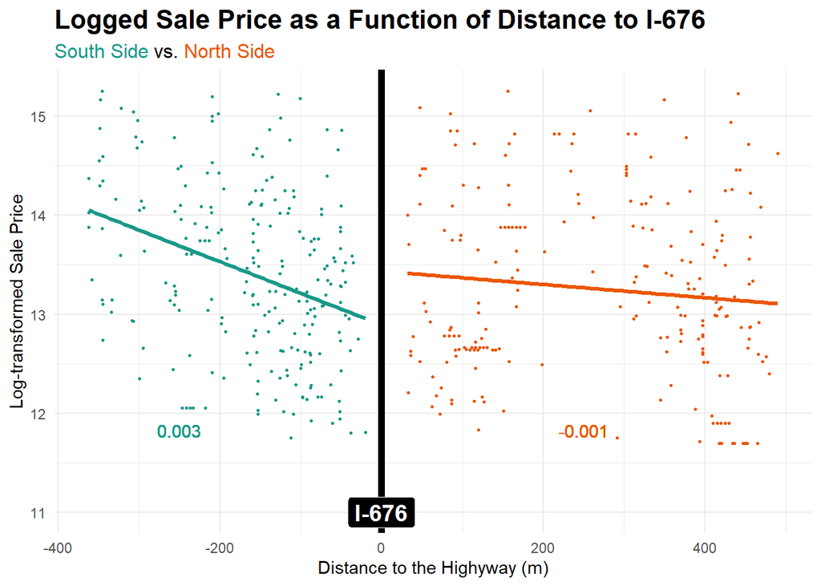

```r
# correlations
# cor_north <- round(cor(discontinuity_plot %>%
#                          filter(
#                            abs(distance_to_highway) <= 500,
#                            I676_NS == "north") %>%
#                          pull(mean_log_price),
#                        discontinuity_plot %>%
#                          filter(
#                            abs(distance_to_highway) <= 500,
#                            I676_NS == "north") %>%
#                          pull(distance_to_highway)), 3)
#
# cor_south <- round(cor(discontinuity_plot %>%
#                          filter(
#                            abs(distance_to_highway) <= 500,
#                            I676_NS == "south") %>%
#                          pull(mean_log_price),
#                        discontinuity_plot %>%
#                          filter(
#                            abs(distance_to_highway) <= 500,
#                            I676_NS == "south") %>%
#                          pull(distance_to_highway)), 3)

# use model coefficients instead of correlations
coef_north_g <- round(
  summary(
    lm(mean_log_price ~ distance_to_highway,
       data = discontinuity_plot %>%
         filter(abs(distance_to_highway) <= 500,
                I676_NS == "north")) # 229 properties
    )$coefficients[2,1], 3) # p = 0.105

coef_south_g <- round(
  summary(
    lm(mean_log_price ~ abs(distance_to_highway), # need to use absolute value cause distance values are negative
       data = discontinuity_plot %>%
         filter(abs(distance_to_highway) <= 500,
                I676_NS == "south")) # 237 properties
    )$coefficients[2,1], 3) # *** p < 0.001

discont_plot <- discontinuity_plot %>%
  filter(abs(distance_to_highway) <= 500) %>% # limiting it to the properties within 500m
  ggplot(aes(x = distance_to_highway, y = mean_log_price, color = I676_NS)) +
  geom_point(size = 0.5) +
  geom_smooth(method = "lm", se = FALSE, size = 1.2) +
  geom_vline(xintercept = 0, color = "black", size = 2) +

  # custom colors
  scale_colour_manual(values = c("#eb5600", "#1a9988")) +

  theme_minimal() +
  theme(legend.position = "None",
        plot.title = element_text(size = 16, face = "bold"),
        plot.subtitle = ggtext::element_markdown(size = 12),
        plot.caption = element_text(hjust = 0)) +
  labs(title = 'Logged Sale Price as a Function of Distance to I-676',
       subtitle = glue("<span style='color:#1a9988;'>South Side</span> vs. <span style='color:#eb5600;'>North Side</span>"),
       x = "Distance to the Highyway (m)",
       y = "Log-transformed Sale Price") +

  # add annotations
  geom_label(aes(x = 0, y = 11, label = "I-676"),
             fill = "black", color = "white", fontface = "bold", size = 5) +
  geom_text(aes(label = coef_north_g,
                x = 250,
                y = 11.825),
            color = "#eb5600",
            show.legend = F) +
  geom_text(aes(label = coef_south_g,
                x = -250,
                y = 11.825),
            color = "#1a9988",
            show.legend = F)

# ungrouped
coef_north <- round(
  summary(
    lm(log_price ~ distance_to_highway,
       data = discontinuity_plot_ungrouped %>%
         filter(abs(distance_to_highway) <= 500,
                I676_NS == "north")) # 609 properties
    )$coefficients[2,1], 3) # p = 0.636

coef_south <- round(
  summary(
    lm(log_price ~ abs(distance_to_highway), # need to use absolute value cause distance values are negative
       data = discontinuity_plot_ungrouped %>%
         filter(abs(distance_to_highway) <= 500,
                I676_NS == "south")) # 811 properties
    )$coefficients[2,1], 3) # *** p < 0.001

discont_plot_ungrouped <- discontinuity_plot_ungrouped %>%
  filter(abs(distance_to_highway) <= 500) %>% # limiting it to the properties within 500m
  ggplot(aes(x = distance_to_highway, y = log_price, color = I676_NS)) +
  geom_point(size = 0.5) +
  geom_smooth(method = "lm", se = FALSE, size = 1.2) +
  geom_vline(xintercept = 0, color = "black", size = 2) +

  # custom colors
  scale_colour_manual(values = c("#eb5600", "#1a9988")) +

  theme_minimal() +
  theme(legend.position = "None",
        plot.title = element_text(size = 16, face = "bold"),
        plot.subtitle = ggtext::element_markdown(size = 12),
        plot.caption = element_text(hjust = 0)) +
  labs(title = 'Logged Sale Price as a Function of Distance to I-676',
       subtitle = glue("<span style='color:#1a9988;'>South Side</span> vs. <span style='color:#eb5600;'>North Side</span>"),
       x = "Distance to the Highyway (m)",
       y = "Log-transformed Sale Price") +

  # add annotations
  geom_label(aes(x = 0, y = 11, label = "I-676"),
             fill = "black", color = "white", fontface = "bold", size = 5) +
  geom_text(aes(label = coef_north,
                x = 250,
                y = 11.825),
            color = "#eb5600",
            show.legend = F) +
  geom_text(aes(label = coef_south,
                x = -250,
                y = 11.825),
            color = "#1a9988",
            show.legend = F)

discont_plot
```

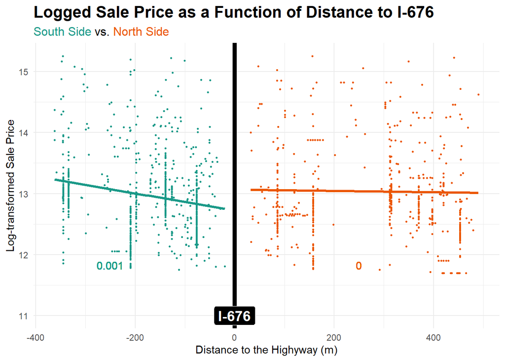

```r
discont_plot_ungrouped
```

```r
# save image for powerpoint
# ggsave("PPT/Images/p2_discontinuity_within_500m.png",
#        height = 7, width = 10, units = "in")
```

In the plot above, we see that on the North side of I-676, property prices remain relatively stable and unaffected by distance to the highway. The median property price in the North is $398,478. When predicting logged property price, the beta coefficient for distance to highway is 0, meaning the **highway has no effect on the price**.

On the other hand, in the South side of I-676, property prices are within the same range of prices as in the North side, but the median property price is slightly higher at $407,069. When predicting logged property price to the South of the highway, the beta coefficient for distance to highway is 0.001, meaning **distance to highway has a very small, positive effect on the price**. For every 1m increase in distance from I-676, property price increases by 0.1%. In more understandable terms, a property that is $100,000 and 50m South of I-676 would be about **$16183 more expensive** a block further from the highway.

This demonstrates that in our study area, the **highway has a very small influence on property price** that is only really seen on the South side of I-676.

# 4 Predictive Modeling

## 4.1 Feature Engineering

### 4.1.1 Continuous Features

### 4.1.2 Categorical Features

### 4.1.3 Summary of Features

## 4.2 Modeling

Built on our simple OLS model, we train four models based on Ordinary Least Squares (OLS), Regularized Linear Regression, Random Forest, and XGBoost respectively for property price predictions:

- **Ordinary Least Squares (OLS)** is a basic linear model that captures simple relationships but struggles with messy or complex data.
- **Regularized Linear Regression (RLS)** improves on OLS by adding penalties to reduce overfitting, making it useful for datasets with many or irrelevant variables.
- **Random Forest (RF)** averages many decision trees built on different data slices, handling complex patterns well but with less interpretability.
- **XGBoost (XGB)** builds trees sequentially, each learning from the last’s errors, excelling in accuracy for structured data tasks.

### 4.2.1 Data Preparation

```r
set.seed(123)
theme_set(theme_bw())

"%!in%" <- Negate("%in%")
g <- glimpse
property_CT_FE <- st_read("E:/Spring/Practicum/DataAnalysis/Chinatown/Dataset/property_CT_FE.geojson") %>%
  st_transform('EPSG:4326')

property_modeling <- property_CT_FE %>%
  mutate(
    Longitude = st_coordinates(.)[, 1],
    Latitude = st_coordinates(.)[, 2]
  ) %>%
  st_drop_geometry() %>%
  mutate(log_distance_to_city_hall = log(distance_to_city_hall +1),
         log_nearest_restaurant_dist_m = log (nearest_restaurant_dist_m +1),
         log_distance_to_nearest_park = log(distance_to_nearest_park +1),
         log_distance_to_nearest_water = log(distance_to_nearest_water+1),
         log_total_livable_area = log1p(total_livable_area),
         log_adj_sale_price = log(adj_sale_price+1)) %>%
  select(log_dist_highway,
         log_distance_to_city_hall,
         log_nearest_restaurant_dist_m,
         log_distance_to_nearest_park,
         zoning_group,
         zip_code,
         exterior_condition,
         interior_condition,
         log_total_livable_area,
         number_of_bathrooms,
         number_of_bedrooms,
         quality_grade,
         log_distance_to_nearest_water,
         central_air,
         year_built_group,
         # year_built,
         LPSS_PER1000,
         general_construction,
         garage_spaces,
         separate_utilities,
         category_code,
         crime_nn5,
         nhoods_name,
         landuse,
         log_adj_sale_price,
         Longitude, Latitude)

property_modeling_geo <- property_modeling %>%
  st_as_sf(coords = c("Longitude", "Latitude"), crs = 4326)

# write.csv(property_modeling, "E:/Spring/Practicum/DataAnalysis/Chinatown/Dataset/property_marketvalue/property_modeling.csv", row.names = FALSE)
# st_write(property_modeling_geo, "E:/Spring/Practicum/DataAnalysis/Chinatown/Dataset/property_marketvalue/property_modeling.geojson")

# Initial Split for Training and Test
set.seed(123)
data_split <- initial_split(property_modeling, strata = "log_adj_sale_price", prop = 0.7)
property_train <- training(data_split)
property_test  <- testing(data_split)


model_rec <- recipe(log_adj_sale_price ~ ., data = property_modeling) %>%
  # update_role(zoning_group, new_role = "zoning_group") %>%
  step_novel(all_nominal()) %>%
  step_other(all_nominal(), threshold = 0.01, other = "rare_level") %>%
  step_unknown(all_nominal()) %>%
  step_nzv(all_nominal()) %>%
  step_dummy(all_nominal()) %>%
  step_ns(Latitude, Longitude, options = list(df = 4),keep_original_cols=TRUE) %>%
  # step_corr(all_numeric_predictors(), threshold = 0.9) %>% # reduce multicollinearity
  step_zv(all_predictors()) %>%
  step_center(all_numeric_predictors()) %>%
  step_scale(all_numeric_predictors())
```

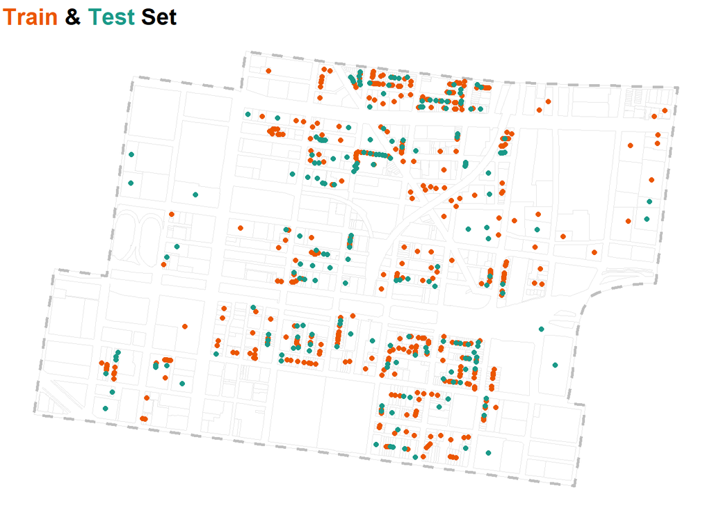

```r
property_train_geo <- property_train %>%
  st_as_sf(coords = c("Longitude", "Latitude"), crs = 4326) %>%
  st_transform('EPSG:2272')
property_test_geo <- property_test %>%
  st_as_sf(coords = c("Longitude", "Latitude"), crs = 4326) %>%
  st_transform('EPSG:2272')
ggplot() +
  geom_sf(data = landuse, fill = "white", color = "gray90", linewidth = 0.3) +
  geom_sf(data = studyarea, fill = "transparent", color = "grey", linetype = "dashed", linewidth = 1) +
  geom_sf(data = property_train_geo, color = "#eb5600") +
  geom_sf(data = property_test_geo, color = "#1a9988") +
  labs(title = glue("<span style='color:#eb5600;'>Train</span> & <span style='color:#1a9988;'>Test</span> Set")) +
  theme_void() +
  theme(plot.title = ggtext::element_markdown(size = 16, face = "bold"))
```

### 4.2.2 Model Training

Within the training set, we use *spatial cross-validation*, which tests the model on different areas to avoid overfitting to nearby properties. *K-means Clustering* is used when creating the cross-validation folds. This helps prevent the model from “cheating” by seeing similar areas in both training and testing.

Each model is trained following a workflow, including defining, tuning, and evaluating. Here, we’d like to take Random Forest workflow as an example.

1. `rf_plan` defines the Random Forest model structure. A Random Forest is a collection of many decision trees. Each tree looks at the data differently, and their combined result gives a more accurate and stable prediction.
2. `rf_grid` is a grid of possible settings (combinations of `mtry` and `min_n`) for tuning. This lets the model try different setups and find what works best.
- `mtry`: How many features to look at when making each split in a tree
- `min_n`: Minimum number of data points a final decision node must have
3. `rf_wf` is a workflow that connects our preprocessing (`model_rec`) and model (`rf_plan`) together. It ensures that all the data is cleaned the same way every time we train or test the model.
4. `rf_tuned` trains many Random Forest models using the different settings from `rf_grid`, and tests each one using our *spatial cross-validation* folds. This is the “try everything and see what works best” step. Each fold helps estimate how well the model will generalize.
5. `rf_best_params` picks the best settings from the tuning process based on which combination gave the *lowest RMSE*. Then `rf_best_wf` finalizes the workflow with the best-performing parameters locked in.
6. `rf_val_fit_geo` finally train the finalized Random Forest on the entire training set and test its accuracy on the test set. This gives the most realistic estimate of how well the model will perform on new, unseen property data.

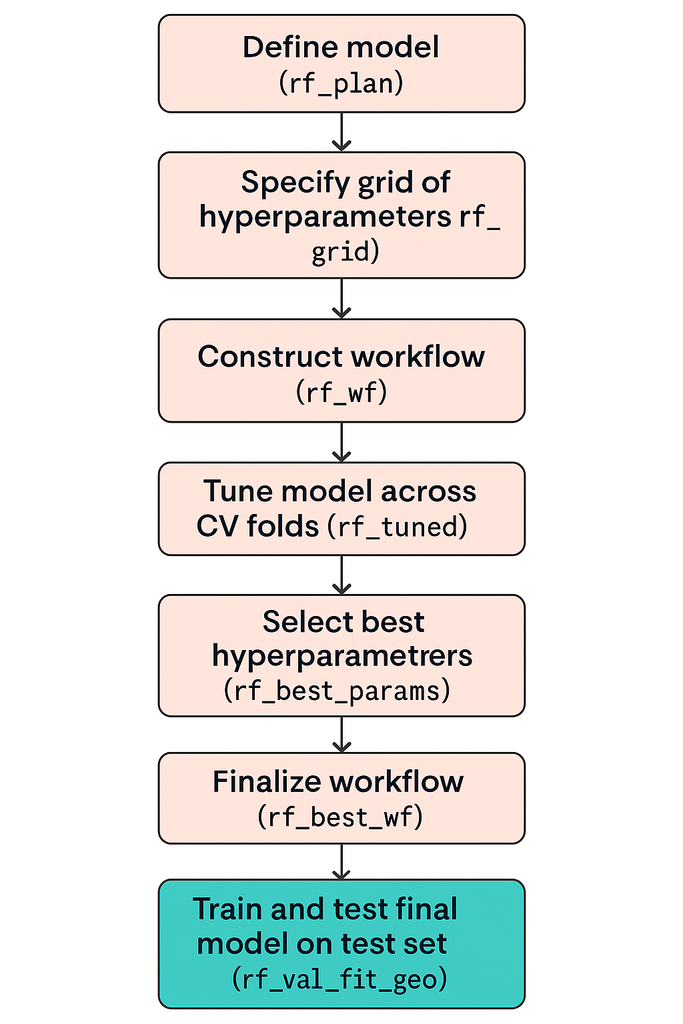

Random Forest Workflow

```r
# Moedl Specifications
lm_plan <-
  linear_reg() %>%
  set_engine("lm")

glmnet_plan <-
  linear_reg() %>%
  set_args(penalty  = tune()) %>%
  set_args(mixture  = tune()) %>%
  set_engine("glmnet")

rf_plan <- rand_forest() %>%
  set_args(mtry  = tune()) %>%
  set_args(min_n = tune()) %>%
  set_args(trees = 1000) %>% # 3000
  set_engine("ranger", importance = "impurity") %>%
  set_mode("regression")

XGB_plan <- boost_tree() %>%
  set_args(mtry  = tune()) %>%
  set_args(min_n = tune()) %>%
  set_args(trees = 100) %>% # smaller
  set_engine("xgboost") %>%
  set_mode("regression")

# Hyperparameter grid

glmnet_grid <- expand.grid(penalty = seq(0, 1, by = .25),
                           mixture = seq(0,1,0.25))
rf_grid <- expand.grid(mtry = c(2,5,10,13,30,45),
                       min_n = c(5,50,100,500)) # 50-250
xgb_grid <- expand.grid(mtry = c(3,5),
                        min_n = c(1,5)) # same as rf

# create workflow
lm_wf <-
  workflow() %>%
  add_recipe(model_rec) %>%
  add_model(lm_plan)
glmnet_wf <-
  workflow() %>%
  add_recipe(model_rec) %>%
  add_model(glmnet_plan)
rf_wf <-
  workflow() %>%
  add_recipe(model_rec) %>%
  add_model(rf_plan)
xgb_wf <-
  workflow() %>%
  add_recipe(model_rec) %>%
  add_model(XGB_plan)

# Spatial CV approach
property_train_sf <- st_as_sf(property_train, coords = c("Longitude", "Latitude"), crs = 4326)
property_train_sf <- property_train_sf %>%
  mutate(
    Longitude = st_coordinates(.)[, 1],
    Latitude = st_coordinates(.)[, 2]
  )
set.seed(123)
cv_splits_zoning <- group_vfold_cv(property_train,
                                group = "zoning_group")
set.seed(123)
cv_splits_cluster <- spatial_clustering_cv(
  property_train_sf,
  v = 20,
  cluster_function = "kmeans"
)

cv_splits_geo <- cv_splits_cluster
control <- control_resamples(save_pred = TRUE, verbose = TRUE)
metrics <- metric_set(rmse, rsq, mape, smape)
```

```r
# fit model to workflow and calculate metrics
lm_tuned <- lm_wf %>%
  tune::fit_resamples(.,
                      resamples = cv_splits_geo,
                      control   = control,
                      metrics   = metrics)

glmnet_tuned <- glmnet_wf %>%
  tune::tune_grid(.,
                  resamples = cv_splits_geo,
                  grid      = glmnet_grid,
                  control   = control,
                  metrics   = metrics)

rf_tuned <- rf_wf %>%
  tune::tune_grid(.,
                  resamples = cv_splits_geo,
                  grid      = rf_grid,
                  control   = control,
                  metrics   = metrics)

xgb_tuned <- xgb_wf %>%
  tune::tune_grid(.,
                  resamples = cv_splits_geo,
                  grid      = xgb_grid,
                  control   = control,
                  metrics   = metrics)

# saveRDS(lm_tuned, "results/lm_tuned.rds")
# saveRDS(glmnet_tuned, "results/glmnet_tuned.rds")
# saveRDS(rf_tuned, "results/rf_tuned.rds")
# saveRDS(xgb_tuned, "results/xgb_tuned.rds")
```

```r
lm_tuned     <- readRDS("Modeling/results/lm_tuned.rds")
glmnet_tuned <- readRDS("Modeling/results/glmnet_tuned.rds")
rf_tuned     <- readRDS("Modeling/results/rf_tuned.rds")
xgb_tuned    <- readRDS("Modeling/results/xgb_tuned.rds")

# 'Best' by some metric and margin
lm_best_params     <- select_best(lm_tuned, metric = "rmse"    )
glmnet_best_params <- select_best(glmnet_tuned, metric = "rmse")
rf_best_params     <- select_best(rf_tuned, metric = "rmse"    )
xgb_best_params    <- select_best(xgb_tuned, metric = "rmse"   )

# Final workflow
lm_best_wf     <- finalize_workflow(lm_wf, lm_best_params)
glmnet_best_wf <- finalize_workflow(glmnet_wf, glmnet_best_params)
rf_best_wf     <- finalize_workflow(rf_wf, rf_best_params)
xgb_best_wf    <- finalize_workflow(xgb_wf, xgb_best_params)

# last_fit() emulates the process where, after determining the best model, the final fit on the entire training set is needed and is then evaluated on the test set.
lm_val_fit_geo <- lm_best_wf %>%
  last_fit(split     = data_split,
           control   = control,
           metrics   = metrics)

glmnet_val_fit_geo <- glmnet_best_wf %>%
  last_fit(split     = data_split,
           control   = control,
           metrics   = metrics)

rf_val_fit_geo <- rf_best_wf %>%
  last_fit(split     = data_split,
           control   = control,
           metrics   = metrics)

xgb_val_fit_geo <- xgb_best_wf %>%
  last_fit(split     = data_split,
           control   = control,
           metrics   = metrics)
```

### 4.2.3 Model Validation and Comparison

After applying the models to the test set, we evaluate and compare models’ accuracy using Mean Absolute Error (MAE), Mean Absolute Percentage Error (MAPE) and prediction v.s. actual value scatter plot.

- **Mean Absolute Error (MAE)**: This tells us how much, on average, our model’s predicted price is off from the real price. For example, if the model says a house is worth $310,000, but it actually sold for $300,000, the error is $10,000. MAE takes the average of all these errors. So if MAE is $15,000, that means our price predictions are usually off by about $15,000.
- **Mean Absolute Percentage Error (MAPE)**: This tells us the size of the prediction error as a percentage of the real price. So instead of saying the model is off by $15,000, it might say it’s off by 5%. MAPE is useful when we’re comparing predictions across properties with different price ranges.
- **Prediction v.s. Actual Value Scatter Plot**: This is a chart that helps us see how close our model’s predictions are to the actual sale prices. Each dot on the chart represents one property. If all the dots are near a straight diagonal line, it means the predictions are very close to the real prices. If they are scattered far away from that line, the model’s predictions are less accurate.

```r
# Pull best hyperparam preds from out-of-fold predictions
lm_best_OOF_preds <- collect_predictions(lm_tuned)

glmnet_best_OOF_preds <- collect_predictions(glmnet_tuned) %>%
  filter(penalty  == glmnet_best_params$penalty[1] & mixture == glmnet_best_params$mixture[1])

rf_best_OOF_preds <- collect_predictions(rf_tuned) %>%
  filter(mtry  == rf_best_params$mtry[1] & min_n == rf_best_params$min_n[1])

xgb_best_OOF_preds <- collect_predictions(xgb_tuned) %>%
  filter(mtry  == xgb_best_params$mtry[1] & min_n == xgb_best_params$min_n[1])

# collect validation set predictions from last_fit model
lm_val_pred_geo     <- collect_predictions(lm_val_fit_geo)
glmnet_val_pred_geo <- collect_predictions(glmnet_val_fit_geo)
rf_val_pred_geo     <- collect_predictions(rf_val_fit_geo)
xgb_val_pred_geo    <- collect_predictions(xgb_val_fit_geo)


# Aggregate OOF predictions (they do not overlap with Validation prediction set)
OOF_preds <- rbind(data.frame(dplyr::select(lm_best_OOF_preds, .pred, log_adj_sale_price), model = "OLS"),
                   data.frame(dplyr::select(glmnet_best_OOF_preds, .pred, log_adj_sale_price), model = "RLS"),
                   data.frame(dplyr::select(rf_best_OOF_preds, .pred, log_adj_sale_price), model = "RF"),
                   data.frame(dplyr::select(xgb_best_OOF_preds, .pred, log_adj_sale_price), model = "XGB")) %>%
  group_by(model) %>%
  mutate(actual_price = exp(log_adj_sale_price) - 1,
         predicted_price = exp(.pred) - 1,
         RMSE = yardstick::rmse_vec(actual_price, predicted_price),
         MAE  = yardstick::mae_vec(actual_price, predicted_price),
         MAPE = mean(abs(predicted_price - actual_price) / actual_price)) %>%
  ungroup() %>%
  mutate(model = factor(model, levels=c("OLS","RLS","RF","XGB")))

# Aggregate predictions from Validation set
# improve MAPE
val_preds <- rbind(data.frame(lm_val_pred_geo, model = "OLS"),
                   data.frame(glmnet_val_pred_geo, model = "RLS"),
                   data.frame(rf_val_pred_geo, model = "RF"),
                   data.frame(xgb_val_pred_geo, model = "XGB")) %>%
  left_join(., property_modeling %>%
              rowid_to_column(var = ".row") %>%
              dplyr::select(Latitude, Longitude, zoning_group, .row),
            by = ".row") %>%
  group_by(model) %>%
  mutate(
    actual_price = exp(log_adj_sale_price) - 1,
    predicted_price = exp(.pred) - 1
  ) %>%
  mutate(
    RMSE = yardstick::rmse_vec(actual_price, predicted_price),
    MAE  = yardstick::mae_vec(actual_price, predicted_price),
    MAPE = mean(abs(predicted_price - actual_price) / actual_price)
  ) %>%
  ungroup() %>%
  mutate(model = factor(model, levels=c("OLS","RLS","RF","XGB")))
```

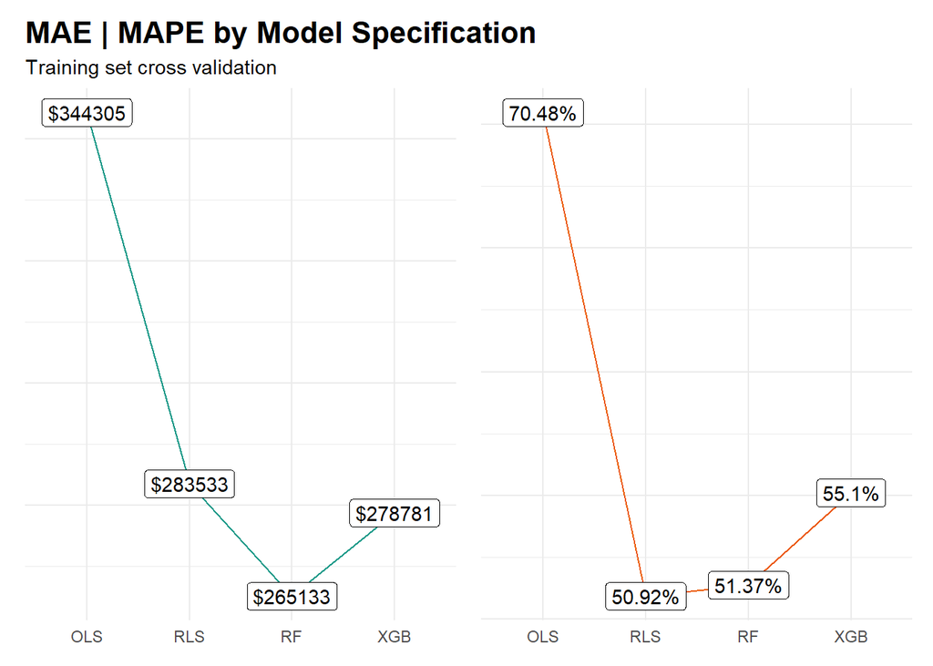

```r
# average error for each model
OOF_plot1 <- ggplot(data = OOF_preds %>%
         dplyr::select(model, MAE) %>%
         distinct() ,
       aes(x = model, y = MAE, group = 1)) +
  geom_path(color = "#1a9988") +
  geom_label(aes(label = paste0("$", round(MAE)))) +
  labs(title = "MAE | MAPE by Model Specification",
       subtitle = "Training set cross validation") +
  theme_minimal() +
  theme(plot.title = ggtext::element_markdown(size = 16, face = "bold"),
        axis.title = element_blank(),
        axis.text.y = element_blank())

OOF_plot2 <- ggplot(data = OOF_preds %>%
         dplyr::select(model, MAPE) %>%
         distinct() ,
       aes(x = model, y = MAPE, group = 1)) +
  geom_path(color = "#eb5600") +
  geom_label(aes(label = paste0(round(MAPE * 100,2),"%"))) +
  theme_minimal() +
  theme(
        axis.title = element_blank(),
        axis.text.y = element_blank())

# OOF predicted versus actual
OOF_plot3 <- ggplot(OOF_preds, aes(x = log_adj_sale_price, y = .pred, group = model)) +
  geom_point(alpha = 0.1, size = 0.5) +
  geom_abline(linetype = "dashed", color = "#1a9988") +
  geom_smooth(method = "lm", color = "#eb5600") +
  coord_equal() +
  facet_wrap(~model, nrow = 2) +
  labs(title = glue("<span style='color:#1a9988;'>Perfect</span> vs. <span style='color:#eb5600;'>Model</span> Prediction"),
       x = "Observed value", y = "Predicted value",
       subtitle = "Training set cross validation") +
  theme_minimal() +
  theme(plot.title = ggtext::element_markdown(size = 16, face = "bold"),
        axis.text = element_blank())

# plot MAPE by model type
val_plot1 <- ggplot(data = val_preds %>%
         dplyr::select(model, MAE) %>%
         distinct() ,
       aes(x = model, y = MAE, group = 1)) +
  geom_path(color = "#1a9988") +
  geom_label(aes(label = paste0("$", round(MAE)))) +
  labs(subtitle = "Test set validation") +
  theme_minimal() +
  theme(plot.title = ggtext::element_markdown(size = 16, face = "bold"),
        axis.title = element_blank(),
        axis.text.y = element_blank())

val_plot2 <- ggplot(data = val_preds %>%
         dplyr::select(model, MAPE) %>%
         distinct() ,
       aes(x = model, y = MAPE, group = 1)) +
  geom_path(color = "#eb5600") +
  geom_label(aes(label = paste0(round(MAPE * 100,2),"%"))) +
  theme_minimal() +
  theme(axis.title = element_blank(),
        axis.text.y = element_blank())

# Validation Predicted vs. actual
val_plot3 <- ggplot(val_preds, aes(x = log_adj_sale_price, y = .pred, group = model)) +
  geom_point(alpha = 0.1, size = 0.5) +
  geom_abline(linetype = "dashed", color = "#1a9988") +
  geom_smooth(method = "lm", color = "#eb5600") +
  coord_equal() +
  facet_wrap(~model, nrow = 2) +
  labs(x = "Observed value", y = "Predicted value",
       subtitle = "Test set validation") +
  theme_minimal() +
  theme(axis.text = element_blank())

OOF_plot1 | OOF_plot2
```

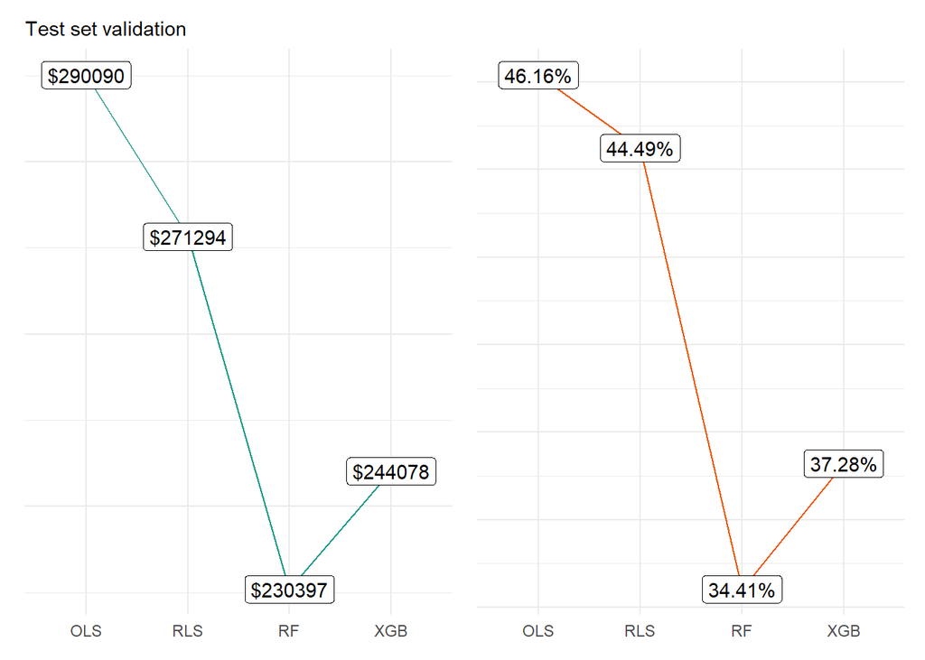

```r
val_plot1 | val_plot2
```

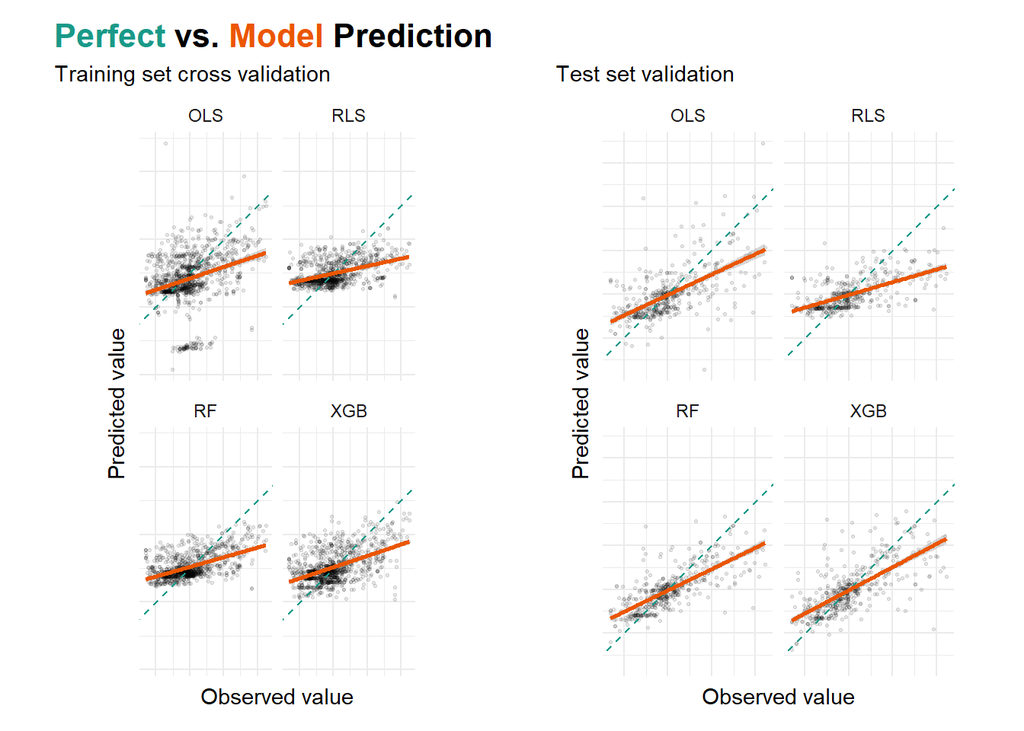

```r
OOF_plot3 | val_plot3
```

```r
intersections <- val_preds %>%
  group_by(model) %>%
  do({
    fit <- lm(.pred ~ log_adj_sale_price, data = .)
    coefs <- coef(fit)
    x_log <- coefs[1] / (1 - coefs[2])  # x = a / (1 - b)
    # y_log <- x_log
    price_orig <- exp(x_log) - 1  # Adjusted for log(price + 1)
    tibble(x_log = x_log, price = price_orig)
  })

intersections %>%
  kbl(align = c("l", rep("c", 2)),
      caption = "Intersections between Model Predictions and Observed Prices",
      col.names = c("Model", "Log Price", "Property Price")) %>%
  kable_styling() %>%
  kable_classic(full_width = F, html_font = "Cambria") %>%
  row_spec(3, bold = T, background = "#7fe3d6")
```

Intersections between Model Predictions and Observed Prices

| Model | Log Price | Property Price |
| --- | --- | --- |
| OLS | 12.97012 | 429388.2 |
| RLS | 12.97954 | 433452.3 |
| RF | 12.95289 | 422052.7 |
| XGB | 12.95686 | 423733.3 |

### 4.2.4 Random Forest Model

# 5 Scenario Planning

## 5.1 Case Studies

# 6 Code Appendix

### 6.0.1 Philadelphia Scale Analysis

```r
# adding distance to highway and log price variables
# properties500 <- philly_properties[hiway_500buff,] %>% # 88571 -> 14751 rows
#   mutate(log_price = log(adj_sale_price),
#          dist_to_US001 = calculate_nearest_distance(geometry,
#                                      philly_highways %>%
#                                        filter(ST_RT_NO == "0001")),
#          dist_to_I076 = calculate_nearest_distance(geometry,
#                                     philly_highways %>%
#                                       filter(ST_RT_NO == "0076")),
#          dist_to_I095 = calculate_nearest_distance(geometry,
#                                     philly_highways %>%
#                                       filter(ST_RT_NO == "0095")),
#          dist_to_I676 = calculate_nearest_distance(geometry,
#                                     philly_highways %>%
#                                       filter(ST_RT_NO == "0676")),
#          dist_to_US001m = dist_to_US001 * 0.3048,
#          dist_to_I076m = dist_to_I076 * 0.3048,
#          dist_to_I095m = dist_to_I095 * 0.3048,
#          dist_to_I676m = dist_to_I676 * 0.3048)
#
# prop500_closest <- properties500 %>%
#   select(matches("objectid|dist_to")) %>%
#   pivot_longer(cols = 2:5,
#                names_to = "highway",
#                values_to = "distance") %>%
#   group_by(objectid) %>%
#   summarise(dist_to_closest_highway = min(distance, na.rm = T)) %>%
#   ungroup()  %>%
#   mutate(dist_to_closest_highwaym = dist_to_closest_highway * 0.3048,
#          log_dist_to_closest_highway = log(dist_to_closest_highway))

# join closest highway
# prop500 <- left_join(properties500,
#                      prop500_closest %>% st_drop_geometry(),
#                      by = "objectid") %>%
#   mutate(closest_highway = case_when(
#     dist_to_closest_highway == dist_to_US001 ~ "US-1",
#     dist_to_closest_highway == dist_to_I076 ~ "I-76",
#     dist_to_closest_highway == dist_to_I095 ~ "I-95",
#     dist_to_closest_highway == dist_to_I676 ~ "I-676",
#     .default = NA),
#     closest_highway = factor(closest_highway, levels = c("US-1", "I-76", "I-676", "I-95")),
#     highway_type = case_when(closest_highway %in% c("US-1","I-676") ~ "through neighborhood",
#                              closest_highway %in% c("I-95","I-76") ~ "along waterway",
#                              .default = NA))

# save output and read in the prefiltered to save time
# st_write(prop500, "akidata/philly_prop500_dst2hghwy_250421.geojson")
```